# Functional annotation & region-level analysis

- Show All Code
- Hide All Code
- View Source

## Annotation and Interpretation

At this point the EWAS is done: we have a per-CpG table of effect sizes and p-values, BACON-adjusted for residual inflation (notebook 06), and — if we chose the stratified route — a METAL meta-analysis of the strata (notebook 07). Next we introduce functional annotation and region-level analysis. Previously it was mentioned that the snakemake pipeline can do differentially methylated region analysis in addition to the EWAS. But, it wasn’t really explained what that is or why you would want to do it. Here we more fully detail functional annotation and secondary analysis (including regional analyses) that are a necessary part in interpretation of results.

1. **CpG-level functional annotation** — attach genomic coordinates, gene context, CpG-island relationship, and expression links to every probe, so the top hits can be read as *“this CpG sits in the promoter of gene X”* rather than *“cg16340178”*.
2. **Region-level analysis (DMRs)** — ask whether *spatially clustered* CpGs move together. A differentially methylated region (DMR) can be highly significant even when no single CpG in it survives genome-wide correction, because neighboring probes are correlated and that correlation carries signal (Pedersen et al. 2012; Peters et al. 2015).

For functional annotation of the EWAS results we use Wanding Zhou’s hg38 EPIC annotation resources (Zhou et al. 2017). Zhou recently (July of 2026) made a major update of his website and released new versions of his resources (v8.1). This tutorial implements some of the newest version of Zhou’s files in addition to some ‘legacy’ files. The Snakemake pipeline uses entirely legacy files at the moment, but will be updated to use the latest versions in the next release. Most of the annotation in this chapter is hg38, but not all of it. The enrichment tools `goregion`, `gometh` and `methylGSA` default to Illumina’s hg19 annotation package; here we pass each of them Zhou’s hg38 annotation instead, but the knowYourCG knowledgebases and the web tools still rest partly or wholly on hg19. The table below lists the build and source behind each section. It matters most where the chapter compares tools, because two tools built on different annotations are not a like-for-like comparison. For tools that take probe IDs rather than coordinates, the build shows up in *which genes or features each probe was assigned to*, not in any coordinate you see.

| Section | Tool | Genome build | Annotation source |
| --- | --- | --- | --- |
| Part 1: gene and CpG-island context | Zhou manifests | hg38 | Zhou, GENCODE v41 and v36 |
| Part 1: eQTM layer | BIOS cis-eQTM catalog | hg19 (original mapping; joined by probe ID) | BIOS consortium, gene symbols re-mapped to current HGNC |
| Part 2: region calling | comb-p, `ENmix::combp` | hg38 | Zhou coordinates |
| Part 2: annotating the DMR | overlap with UCSC tables | hg38 | UCSC refGene, cpgIslandExt, HGNC |
| Part 2: region enrichment | `missMethyl::goregion` | hg38 | Zhou, GENCODE v41 (passed with `anno =`) |
| Part 3: gene-set enrichment | `missMethyl::gometh` | hg38 | Zhou, GENCODE v41 (passed with `anno =`) |
| Part 3: gene-set enrichment | `methylGSA` | hg38 | Zhou, GENCODE v41 (passed with `FullAnnot =`) |
| Part 3: regulatory-feature enrichment | knowYourCG | hg38, except chromatin states (hg19) | Zhou knowledgebases (Cistrome, Roadmap) |
| Part 3: web tools | EWAS Toolkit, eFORGE | hg19 | Illumina; Roadmap/ENCODE |

The three tables used for annotation, all downloadable from the [zhou-lab GitHub](https://github.com/zhou-lab/InfiniumAnnotationData) are:

- **`EPIC.hg38.manifest.gencode.v41.tsv.gz`** — gene model: gene names, transcript biotypes, and signed distance to the nearest TSS.
- **`EPIC.hg38.manifest.gencode.v36.tsv.gz`** — the v36 table additionally carries the CpG-island (CGI) relation column we use for island context.
- **`EPIC.hg38.coord.tsv.gz`** — remapped hg38 coordinates. Note this table is keyed by genomic position and carries no `probeID` column, so it cannot be merged onto results by probe; the v41 manifest above already supplies `CpG_chrm`/`CpG_beg`/`CpG_end` and is what we actually join.

Methylation is often a mediator of change. The environment can cause changes to methylation, which subsequently causes change in gene expression. Methylation sites that cause changes in gene expression are called expression quantitative trait methylation sites (eQTMs). So, one additional external layer, the **BIOS cis-eQTM catalog** (whole-blood methylation→expression links) was added to expand the functional annotation. This helps identify which (if any) effector gene may be behind methylation change. I recommend reading more into the BIOS eQTM catalog more before using and reporting the results as there are some distinct limitations (only 450k methylation array probes were tested, European-ancestry only cohort, original analysis uses hg19 mapping). This part of the functional annotation was added to the EWAS Snakemake upon request from a reviewer for the information.

**NoteThis notebook and the Snakemake pipeline**

The krferrier/EWAS pipeline automates part of this chapter — its `annotate.smk` and `dmr.smk` rules run the same annotation join and the same `comb-p` region detection we walk through manually. It does not yet run pathway enrichment (Part 3); that is planned for the next update. We reproduce the steps by hand so the logic is clearly layed out.

```r
library(data.table)      # fread()/fwrite(): fast reading and writing of the large tables
library(dplyr)           # filter(), mutate(), left_join() and the other table verbs
library(tibble)          # rownames_to_column(), for the gometh KEGG table in Part 3
library(ggplot2)         # the two context bar charts in Part 1
```

## Part 1 — CpG-level functional annotation

### What annotation resources exist, and which to trust

An EPIC probe ID like `cg16340178` is the Illumina name for a CpG. To interpret it we need to know **where it lands in the genome** and **what functional element it tags**. Historically people reached for the hg19 Illumina/minfi manifest for this, but its coordinates are a genome build behind current references and its gene mapping is generous (it lists any transcript overlapping the probe). Zhou’s resources supersede it:

| Zhou hg38 table | What it gives | Column(s) we use |
| --- | --- | --- |
| `manifest.gencode.v41` | gencode v41 gene model | `genesUniq`, `transcriptTypes`, `distToTSS` |
| `manifest.gencode.v36` | earlier gene model that also carries CGI relation | `CGIposition` (Island / N_/S_Shore / N_/S_Shelf / open sea) |
| `coord` | remapped hg38 coordinates | `CpG_chrm`, `CpG_beg`, `CpG_end` |
| BIOS cis-eQTM (Bonder et al. 2017) *(external)* | genes whose *expression* tracks the CpG’s methylation in whole blood | likely downstream effector gene |

### The annotation join

We start from the BACON-adjusted top-table saved in chapter 06 and left-join the Zhou tables on probe ID. The v41 gene table can list several TSS distances per probe (one per transcript); we keep the nearest, which is what defines the promoter call below.

**NoteWhat this section needs**

This section starts from `data/06_ewas_bacon_toptable.csv.gz`, written by chapter 06. If you did not run that chapter, fetch the published checkpoint instead:

```
Terminal
```

```bash
./get_data.sh F_ewas_results
```

```r
# The two Zhou gencode manifests are read straight from the zhou-lab repository.
zhou_epic <- paste0("https://raw.githubusercontent.com/zhou-lab/InfiniumAnnotationData/",
                    "6d176d6e7e56465403d4478a09fe11b983eeb721/Anno/EPIC/")

# 1. EWAS results: the BACON-adjusted toptable from chapter 06
tt <- fread("data/06_ewas_bacon_toptable.csv.gz", data.table = FALSE)

# 2. Zhou gencode v41 gene model: gene names, biotypes, signed distance to TSS
v41 <- fread(paste0(zhou_epic, "EPIC.hg38.manifest.gencode.v41.tsv.gz"), data.table = FALSE)
# a probe with several transcripts has several distToTSS values (';'-joined);
# keep the one nearest the TSS — this is what the promoter definition uses
nearest_tss <- function(x) {
  v <- suppressWarnings(as.numeric(strsplit(x, ";")[[1]]))
  if (all(is.na(v))) return(NA_real_)
  v[which.min(abs(v))]
}
# one function call per probe over the whole manifest: the slow line here
v41 <- v41 %>% mutate(distTSS = vapply(distToTSS, nearest_tss, numeric(1)))

# 3. CpG-island relation — only the v36 gene table carries CGIposition
v36 <- fread(paste0(zhou_epic, "EPIC.hg38.manifest.gencode.v36.tsv.gz"),
             select = c("probeID","CGIposition"), data.table = FALSE)
v36 <- v36 %>%
  mutate(island = if_else(is.na(CGIposition) | CGIposition == "", "OpenSea", CGIposition))

# 4. Join everything on probe ID.
#    left_join(): every tested CpG stays in the table, annotated or not.
annotated <- tt %>%
  left_join(v41 %>% select(probe = probeID, CpG_chrm, CpG_beg, CpG_end,
                          genesUniq, transcriptTypes, distTSS), by = "probe") %>%
  left_join(v36 %>% select(probe = probeID, island), by = "probe")

# 5. Zhou's gene-feature convention: the gene model runs from 1.5 kb upstream of
#    the TSS through the termination site. A probe within +/-1.5 kb of a TSS is
#    promoter-associated; genic but beyond that is gene body; no gene is intergenic.
annotated <- annotated %>%
  mutate(feature = if_else(is.na(genesUniq) | genesUniq %in% c("", "NA"), "Intergenic",
                   if_else(!is.na(distTSS) & abs(distTSS) <= 1500, "Promoter", "Gene body")))
# rank by the BACON p-value
annotated <- annotated %>% arrange(bacon.p)

# The deposited table is written a few sections down, after the eQTM columns are
# joined on, so that the file on disk carries every annotation this chapter builds.
```

On our Grady PTSD subset this annotates all **756,251** CpGs with hg38 coordinates and maps **647,034** (85.6%) to at least one gencode v41 gene. The remaining ~14% are intergenic. This is expected since a large fraction of the EPIC array deliberately targets enhancers and open sea away from genes.

### The annotated top hits

```r
t10 <- head(annotated, 10) %>%
  mutate(
    # an intergenic probe has no symbol; print a dash rather than NA
    gene = if_else(is.na(genesUniq) | genesUniq == "", "-", genesUniq),
    distToTSS = round(distTSS),
    # delta_beta is chapter 06's case−control β difference; ×100 puts it in
    # percentage points, which is how the prose discusses effect sizes
    "\u0394\u03b2 (pp)" = round(100 * delta_beta, 2),
    "BACON p"   = signif(bacon.p, 3),
    "BACON FDR" = signif(bacon.adj.P, 3)) %>%
  # keep the display columns, in display order, renaming as they are picked
  select(probe, chr = CpG_chrm, pos = CpG_beg, gene, distToTSS, feature, island,
         "\u0394\u03b2 (pp)", "BACON p", "BACON FDR")
fwrite(t10, "data/08_annotation/top10_display.csv")
```

```r
# written by the `top10-derive` chunk above
t10 <- fread("data/08_annotation/top10_display.csv", data.table = FALSE)
knitr::kable(t10, caption = "Top 10 CpGs by BACON-adjusted p-value, with hg38 coordinates and gene/island context.")
```

Top 10 CpGs by BACON-adjusted p-value, with hg38 coordinates and gene/island context.

| probe | chr | pos | gene | distToTSS | feature | island | Δβ (pp) | BACON p | BACON FDR |
| --- | --- | --- | --- | --- | --- | --- | --- | --- | --- |
| cg15434749 | chr8 | 6391843 | - | NA | Intergenic | OpenSea | -2.59 | 2.0e-07 | 0.0901 |
| cg20600436 | chr2 | 180911725 | SCHLAP1 | 219622 | Gene body | OpenSea | 1.41 | 2.0e-07 | 0.0901 |
| cg25717994 | chr13 | 77919495 | EDNRB;OBI1-AS1 | -12 | Promoter | S_Shore | 0.59 | 4.0e-07 | 0.0944 |
| cg02045051 | chr8 | 134784106 | ENSG00000279518;ENSG00000289405 | 1773 | Gene body | OpenSea | -0.71 | 6.0e-07 | 0.1020 |
| cg18321729 | chr15 | 72231987 | PKM | -168 | Promoter | S_Shore | -0.53 | 7.0e-07 | 0.1020 |
| cg26807989 | chr7 | 110090598 | - | NA | Intergenic | OpenSea | 2.68 | 8.0e-07 | 0.1030 |
| cg26747885 | chr17 | 78359619 | SOCS3;SOCS3-DT | 455 | Promoter | Island | 0.43 | 1.2e-06 | 0.1270 |
| cg21429492 | chr18 | 46663672 | - | NA | Intergenic | OpenSea | -1.62 | 2.0e-06 | 0.1750 |
| cg05825555 | chr4 | 25926237 | SMIM20 | 11929 | Gene body | OpenSea | 2.38 | 2.1e-06 | 0.1750 |
| cg07805542 | chr1 | 9719250 | PIK3CD | 401 | Promoter | S_Shelf | 7.66 | 2.5e-06 | 0.1860 |

Now the list has biological context. The top-ranked CpG **cg15434749** is intergenic open sea on chr8 with no nearby gencode v41 gene. **cg25717994** sits essentially on the `EDNRB` TSS (distToTSS = −12 bp, so **promoter** by Zhou’s ±1.5 kb rule); **cg18321729** tags the `PKM` promoter (−168 bp); **cg26747885** is in a CpG island (`Island`) at the `SOCS3` TSS (distToTSS = 455 bp). Four of the top ten fall within 1.5 kb of a TSS. The trend of top-ranked CpGs being in a promotor region is not seen in this analysis, but may appear in a full scale, well-powered EWAS. No CpG clears the Bonferroni significance threshold (the top CpG has BACON p ≈ 2.0 × 10⁻⁷ against a threshold of ≈ 6.6 × 10⁻⁸), and none passes FDR < 0.05 (lowest BACON FDR 0.090). Read this table as ‘nominally significant’ rather than ‘statistically significant’.

In a real study this table is the hand-off point to the enrichment tools in Part 3 and to comparison against published EWAS catalogs.

### Where the top hits sit relative to genes and islands

A useful sanity check is to compare the distribution of the top-ranked CpGs across gene features and island context against the array background. A well-powered signal often enriches in promoters and island shores.

```r
# The two figures below, and the percentages their captions quote. Needs
# `annotated` from the join above; the PNGs it writes are the ones included
# underneath.
TOPN <- 1000
top  <- head(annotated, TOPN)          # `annotated` is already ordered by bacon.p

# One helper for both panels: tabulate a column in the top set and in the whole
# tested set, then convert to a percentage *within* each set, because the two
# sets differ in size by three orders of magnitude and raw counts would not be
# comparable.
mk <- function(col, lev) {
  a <- data.frame(set = "Top 1,000",  grp = factor(top[[col]], levels = lev))
  b <- data.frame(set = "All tested", grp = factor(annotated[[col]], levels = lev))
  bind_rows(a, b) %>%
    filter(!is.na(grp)) %>%
    count(set, grp) %>%                     # number of CpGs per set and category: column n
    group_by(set) %>%
    mutate(pct = 100 * n / sum(n)) %>%      # percentage within each set
    ungroup() %>%
    # top set first, so the series the reader is asking about leads the legend
    mutate(set = factor(set, levels = c("Top 1,000", "All tested")))
}
fd <- mk("feature", c("Promoter", "Gene body", "Intergenic"))
# island levels in genomic order: island, its two shores, its two shelves, then
# everything else — alphabetical order would scramble that
id <- mk("island", c("Island","N_Shore","S_Shore","N_Shelf","S_Shelf","OpenSea"))

ctx_plot <- function(d, xlab) {
  ggplot(d, aes(grp, pct, fill = set)) +
    geom_col(position = position_dodge(width = 0.8), width = 0.7) +
    scale_fill_manual(values = c(`Top 1,000`  = "#1A6B75",   # teal
                                 `All tested` = "#B8873F"),  # sand
                      name = NULL) +
    labs(x = xlab, y = "% of CpGs")
}
ggsave("data/08_annotation/08_feature_distribution.png",
       plot = ctx_plot(fd, "gene feature (Zhou gencode v41)"),
       width = 7, height = 3.2, dpi = 300)
ggsave("data/08_annotation/08_island_distribution.png",
       plot = ctx_plot(id, "CpG-island relation (Zhou CGI)"),
       width = 7, height = 3.2, dpi = 300)
```

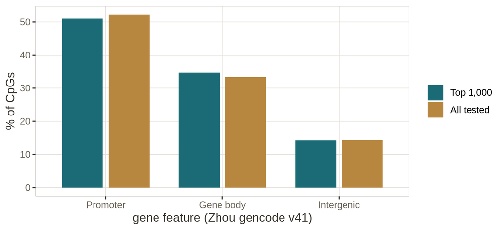

Figure 1: Gene-feature context of the top 1,000 CpGs versus all 756,251 tested, using Zhou’s promoter (±1.5 kb of TSS) / gene-body / intergenic scheme. The top set leans slightly away from promoters (51.0% vs 52.2%) and toward gene bodies (34.7% vs 33.4%), with intergenic essentially unchanged (14.3% vs 14.4%) — not the direction a real signal usually moves, and a small effect at this sample size.

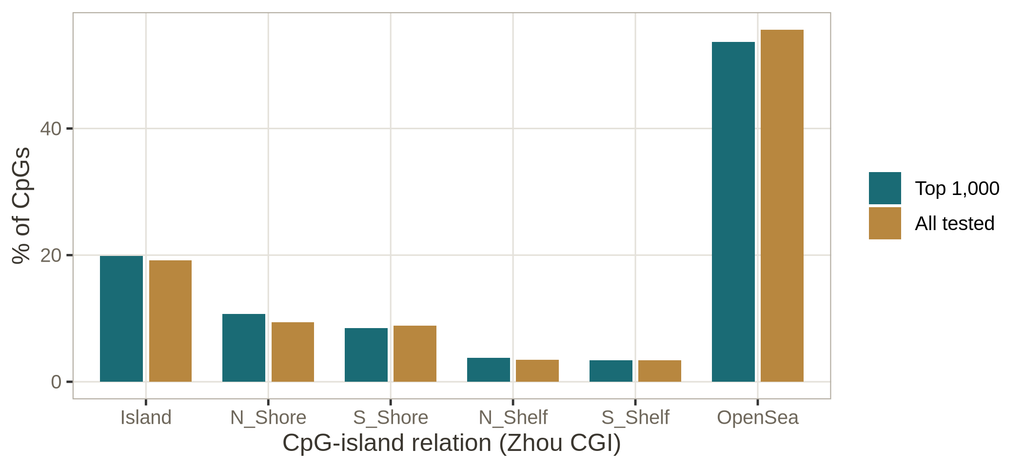

Figure 2: CpG-island context, same comparison, using the Zhou CGI relation. A slight lean toward islands in the top set (19.9% vs 19.2%) and away from open sea (53.7% vs 55.6%). Hold this impression loosely: the formal test in Part 3 (Know Your CpG, another Zhou resource) does *not* find it significant.

The distributions move only modestly between the top 1,000 and the background (Figure 1, Figure 2). The top-set leans slightly toward islands but not toward promoters, and it’s not clear if that pattern is more than chance. The bar chart above is a useful visual indicator, but not a formal enrichment test, which is covered in Part 3 of this chapter.

### The BIOS eQTM layer: methylation that tracks expression

Annotated methylation data often includes a column with the ‘nearest gene’ to the CpG. This is a useful annotation for identifying where in the genome the CpG is physically located and can hint at potential functional impact. For example, evidence of methylation at CpG in a promotor region of a gene could indicate a cis-effect between the CpG and expression of that gene. However, in reality, DNA sequence is not linear, it has 3-dimensional structure. In 3D space, the ‘nearest gene’ in terms of base-pairs may not be the gene that the methylation site is having an effect on. The answer we really want is is whether a CpG actually affects gene expression. The BIOS consortium answered this directly by pairing whole-blood methylation with RNA-seq in ~3,000 samples and testing every cis CpG–transcript pair, producing a catalog of **cis-eQTMs** (Bonder et al. 2017). This information provides the likely *effector* gene behind a methylation change — which is not necessarily the nearest gene.

**NoteBIOS consortium meQTL catalogs**

The BIOS consortium also provides catalogs for cis- and trans-meQTLs (methylation Quantitative Trait Loci), which provide evidence of genetic loci that cause changes to methylation status. This annotation information was not incorporated into the snakemake pipeline and how to merge it in will not be covered in this tutorial as it would require lifting over that data from hg19 to hg38 and only represents meQTLs for CpGs from the 450k array. If you have both methylation and genetic data for your sample, which is often the case, you can perform cis- and trans-meQTL testing yourself. The eQTM relationships require having gene expression and methylation data, which is less common and why the effort was made to liftover and update the eQTM data from the BIOS consortium.

The catalogs are keyed on Ensembl gene IDs; the pipeline’s `prepare_bios_eqtm_annotation.R` helper re-maps those to current HGNC symbols for eQTM data.

**NoteWhat this section needs**

This section reads `data/08_annotation/bios_eqtm_hgnc_annotated.tsv.gz`, which is committed to the repository, so there is nothing to fetch. It is the output of a script from the EWAS snakemake pipeline, `prepare_bios_eqtm_annotation.R`. Please refer to the source code in the [EWAS repo](https://github.com/krferrier/EWAS) if you’d like to rebuild this file yourself.

```r
# Extends `annotated` from the join above. The two files it writes at the end
# are the ones every later section of this chapter reads.

eqtm <- fread("data/08_annotation/bios_eqtm_hgnc_annotated.tsv.gz", data.table = FALSE)

# collapse to one row per CpG: effector gene(s) + strongest eQTM FDR
eq <- eqtm %>%
  filter(HGNCName_GRCh38 != "" & !is.na(HGNCName_GRCh38)) %>%
  group_by(probe = SNPName) %>%
  summarise(BIOS_eQTM_genes  = paste(sort(unique(HGNCName_GRCh38)), collapse = ";"),
            BIOS_eQTM_minFDR = min(as.numeric(FDR), na.rm = TRUE))

# left_join() keeps every row of `annotated`, still in bacon.p order
annotated <- left_join(annotated, eq, by = "probe")

# --- what Part 1 hands on -------------------------------------------------
# Export the annotation data as a .csv (as is found in the Zenodo tier H_annotation) and an RDS.
fwrite(annotated, "data/08_annotation/PTSD_ewas_annotated_zhou.csv.gz")
saveRDS(annotated, "data/08_annotation/annotated.rds")
```

On our subset the eQTM layer annotates **10,803 of the 756,251** tested CpGs (1.4%) with at least one expression-linked effector gene. I will reiterate, there are so few annotations because the BIOS eQTM catalog was curated using the 450k methylation array, and not all probes used in the 450k array were included in the 850k array. In addition, the BIOS catalog only keeps pairs at FDR < 0.05. That said, if we filter our results to look our top EWAS hits that *do* carry an eQTM, we see that the nearest-gene and effector-gene can differ:

```r
# The twelve rows rendered below: the best-ranked hits that carry an eQTM.
eqd <- annotated %>%
  filter(!is.na(BIOS_eQTM_genes)) %>%
  slice_head(n = 12)
# Is the effector gene also the nearest gene? TRUE when any eQTM gene appears in
# the probe's own (semicolon-separated) gene list. mapply because both sides are
# strings that have to be split row by row.
eqd <- eqd %>%
  mutate(nearest = if_else(mapply(function(g, e) {
      if (is.na(g) || g == "") return(FALSE)
      any(strsplit(e, ";")[[1]] %in% strsplit(g, ";")[[1]])
    }, genesUniq, BIOS_eQTM_genes), "yes", "no"))
eqdisp <- eqd %>%
  mutate(nearest_gene = if_else(is.na(genesUniq) | genesUniq == "", "-", genesUniq),
         eQTM_FDR = signif(BIOS_eQTM_minFDR, 3),
         bacon_p  = signif(bacon.p, 3)) %>%
  select(probe, nearest_gene, eQTM_gene = BIOS_eQTM_genes, `nearest?` = nearest,
         eQTM_FDR, bacon_p)
fwrite(eqdisp, "data/08_annotation/eqtm_display.csv")

# the same hits, untrimmed and with every annotation column, for anyone who
# wants to look further down the ranking than the table below shows
annotated %>%
  filter(!is.na(BIOS_eQTM_genes)) %>%
  slice_head(n = 200) %>%
  fwrite("data/08_annotation/eqtm_top_hits.csv")
```

```r
# written by the `eqtm-top-derive` chunk above
knitr::kable(fread("data/08_annotation/eqtm_display.csv", data.table = FALSE),
  caption = "Top EWAS hits (by BACON p) that carry a BIOS cis-eQTM. The 'nearest?' column flags where the expression-linked effector gene is not the nearest gene by distance.")
```

Top EWAS hits (by BACON p) that carry a BIOS cis-eQTM. The ‘nearest?’ column flags where the expression-linked effector gene is not the nearest gene by distance.

| probe | nearest_gene | eQTM_gene | nearest? | eQTM_FDR | bacon_p |
| --- | --- | --- | --- | --- | --- |
| cg12218747 | CBR1-AS1;SETD4 | CBR1 | no | 0.000000 | 7.10e-06 |
| cg26713179 | ZNF766 | ZNF528;ZNF528-AS1;ZNF880 | no | 0.000000 | 1.76e-05 |
| cg08632701 | CBR1-AS1;SETD4 | CBR1 | no | 0.000000 | 5.28e-05 |
| cg09138671 | TMCO4 | TMCO4 | yes | 0.000232 | 6.45e-05 |
| cg19351838 | MMP17 | MMP17 | yes | 0.000000 | 1.21e-04 |
| cg25535873 | HLA-DOA | HLA-DOA | yes | 0.028900 | 3.45e-04 |
| cg26246807 | ZIK1 | ZNF154;ZNF772 | no | 0.001740 | 3.76e-04 |
| cg18786374 | STRADB;TRAK2 | TRAK2 | yes | 0.006920 | 4.27e-04 |
| cg09253696 | ENSG00000267801;TRIM47 | TRIM47 | yes | 0.000000 | 4.33e-04 |
| cg07088771 | TNXB | C4A;C4B;NELFE;SKIC2;TNXA;TNXB;WHR1B | yes | 0.000000 | 5.84e-04 |
| cg13155648 | ANKRD60;PPP4R1L | PPP4R1L | yes | 0.000723 | 6.84e-04 |
| cg23647554 | ZBTB47 | ZBTB47 | yes | 0.000000 | 6.92e-04 |

For **cg12218747** the nearest genes are `CBR1-AS1`/`SETD4`, but the CpG’s methylation tracks the expression of **`CBR1`**. For **cg26713179** the nearest gene is `ZNF766` while the eQTM points at the neighboring **`ZNF528`/`ZNF880`** cluster. Four of these twelve hits show an effector that differs from the nearest gene. When reporting results, the effector gene is usually the one people want to know about if the information is available.

## Part 2 — Region-level analysis (DMRs)

### Why look at regions at all

Single-CpG EWAS tests each probe independently, but methylation is not evenly spaced throughout the genome, and methylation arrays tend to target CpG islands and gene promotor regions where there are likely to be multiple methylation sites close together. Methylation sites in close proximity to each other are likely to have the same methylation status. A region with several unmethylated CpGs is a stronger biological indicator that is an actively expressed region than a single unmethylated CpG, and vice versa for methylated regions. This phenomenon in statistics is called spatial autocorrelation. A cluster of five or six adjacent CpGs each at p ≈ 10⁻⁴ when tested individually (not reaching statistical significance in an EWAS) is, collectively, a statistically significant region.

### DMR tools

The choice of DMR tool is constrained by **what upstream modeling you did**.

**Importantcomb-p works on summary statistics; DMRcate needs line-level data**

**`comb-p`** (Pedersen et al. 2012) takes only a BED-style formatted file of per-CpG p-values and coordinates. It never sees the samples or line-level methylation or phenotype data. That means it works downstream of *any* EWAS model, however complex. If your analysis plan involves stratification and meta-analysis, comb-p is the tool to use. This is why the Snakemake pipeline uses **comb-p**.

**`DMRcate`** (Peters et al. 2015) takes **line-level β/M values plus a single design formula** and re-fits the model internally to compute a smoothed, region-level statistic. It is powerful and self-contained, but it **cannot consume meta-analyzed results** — there is no single design matrix that represents *“stratify by sex, then inverse-variance meta-analyze.”* If you used the stratified-meta workflow, DMRcate is not an option; if you fit one pooled model with sex as a covariate, it is.

### Running comb-p on our EWAS results

`comb-p`’s `pipeline` command chains four steps: estimate the spatial autocorrelation function (ACF) of the p-values, use it to compute autocorrelation-adjusted regional p-values (the Stouffer–Liptak–Kechris correction), FDR-correct those, and finally stitch adjacent low-p CpGs into regions. First we write the BED (this is the pipeline’s `make_bed.R`). The p-values come straight from the chapter 06 BACON fit; the coordinates come from the same Zhou v8.1 hg38 release the chapter 03 mask came from, so the BED and the mask cannot drift apart:

**NoteWhat this section needs**

This section starts from `data/06_ewas.rds`, written by chapter 06. If you did not run that chapter, fetch the published checkpoint instead:

```
Terminal
```

```bash
./get_data.sh F_ewas_results
```

It also needs the probe-order and hg38 coordinate tables from the same Zhou v8.1 release chapter 03 used. You do not need to fetch either: the probe ordering is the copy chapter 03 already committed under `data/`, and the coordinate table is read directly from the Zhou lab’s repository in the chunk below.

```r
# This chunk writes the file comb-p needs for input.
tt  <- readRDS("data/06_ewas.rds")$tt
# The YAME probe order and the coordinate table are two halves of one file pair:
# row i of the coordinate table is the probe named on row i of the ordering
# file, which is why they are assembled side by side and not merged.
# The ordering is the same committed file chapter 03 reads. The coordinate table
# (5 MB) is downloaded from the zhou-lab/InfiniumAnnotation repository, pinned to a
# commit so it cannot change underneath the ordering it has to line up with.
ord <- fread("data/EPIC.ordering.tsv.gz", select = "Probe_ID",    # YAME probe order
             data.table = FALSE)
crd <- fread(paste0("https://raw.githubusercontent.com/zhou-lab/InfiniumAnnotation/",
                    "e91f9e992cc60f2f52f15c564e359ac6718d4cfd/EPIC/EPIC.hg38.coord.tsv.gz"),
             data.table = FALSE)                                   # same order, one row per probe
map <- data.frame(probe = ord$Probe_ID,
                  CpG_chrm = crd$CpG_chrm, CpG_beg = crd$CpG_beg)

# inner_join(): only probes that are both tested and in the coordinate table
bed <- inner_join(tt, map, by = "probe") %>%
  # comb-p walks ordered positions along a chromosome, so keep the assembled
  # chromosomes only: a probe on a scaffold has no neighbors to borrow from
  filter(grepl("^chr([0-9]+|X|Y)$", CpG_chrm)) %>%
  # comb-p's column contract: chrom/start/end, the p-value it smooths, and an
  # id it carries through untouched. The '#' on the first name is what makes
  # the header a comment line to the tool.
  mutate(end = CpG_beg + 2L) %>%
  select(`#chrom` = CpG_chrm, start = CpG_beg, end, pvals = bacon.p, cpgid = probe) %>%
  # order along each chromosome; probes that share a position are ordered by ID
  arrange(`#chrom`, start, cpgid)
fwrite(bed, "data/08_annotation/PTSD_ewas_annotated_results.bed", sep = "\t")
```

That writes **756,234** of the 756,251 tested CpGs — the 17 that fall on unplaced or alt contigs are dropped, because comb-p works on ordered positions along a chromosome and a scaffold has no neighbors to borrow from.

Then the region detection, with the pipeline’s default parameters (`config.yml`: `min_pvalue = 1e-4`, `window_size = 200`, `region_filter = 0.05`):

comb-p is a Python tool with its own environment (`conda env create -f envs/combp.yml`); run the command below in a terminal from the `tutorial/` folder. Its seven output files are committed under `data/08_annotation/dmr/`, so the R chunks that follow run whether or not you run it. `--seed` is the p-value a CpG must reach to start a region, and `--dist` is how far apart (in bp) neighbouring CpGs can be and still extend it:

```
Terminal
```

```bash
mkdir -p data/08_annotation/dmr
comb-p pipeline \
    --seed 1e-4 \
    --dist 200 \
    --region-filter-p 0.05 \
    -p data/08_annotation/dmr/PTSD_dmr \
    data/08_annotation/PTSD_ewas_annotated_results.bed
```

That one command writes seven files, all sharing the `-p` prefix. Nothing prints the answer to screen, so it is worth knowing which file holds what:

| file | contents |
| --- | --- |
| `PTSD_dmr.args.txt` | the exact invocation, the comb-p version, and the run date — keep this for your methods section |
| `PTSD_dmr.acf.txt` | the fitted autocorrelation function: `lag_min`, `lag_max`, `correlation`, `N`, `p` |
| `PTSD_dmr.slk.bed.gz` | every input CpG with its smoothed regional p: `#chrom`, `start`, `end`, `p` (your input p), `region-p` (SLK-smoothed) |
| `PTSD_dmr.fdr.bed.gz` | the same rows plus `region-q`, the Benjamini–Hochberg correction of `region-p` |
| `PTSD_dmr.regions.bed.gz` | the stitched regions, minimal and headerless: chrom, start, end, `min_p`, `n_probes` |
| `PTSD_dmr.regions-p.bed.gz` | the regions with statistics: `#chrom`, `start`, `end`, `min_p`, `n_probes`, `z_p`, `z_sidak_p` |
| `PTSD_dmr.regions-t.bed` | the regions that pass `--region-filter-p` — here the single region with `z_sidak_p` < 0.05 |

`regions-p.bed.gz` is the file to read: it lists every candidate region with both the uncorrected and the Šidák-corrected region p. `regions-t.bed` is that same table filtered down to what survived, which makes it the convenient endpoint for a pipeline. In this run the two files carry identical columns because our input BED has no effect-size column for comb-p to carry through.

The ACF step reports short-range autocorrelation in our p-values (correlation ≈ 0.054 out to ~71 bp, p ≈ 2.0 × 10⁻¹²⁸ over 202,078 CpG pairs). Methylation *is* spatially structured here, as expected. The SLK/FDR steps then propose two candidate regions, and one of them survives the Šidák correction for the number of regions tested:

| region (hg38) | n CpGs | `min_p` | `z_sidak_p` |
| --- | --- | --- | --- |
| chr6:28,633,493–28,633,701 | 11 | 8.3 × 10⁻¹⁴ | **2.4 × 10⁻¹⁶** |
| chr3:138,608,544–138,608,573 | 2 | 9.3 × 10⁻⁵ | 0.53 |

Those are five of the seven columns in `regions-p.bed.gz` — the three coordinate columns are collapsed into one here, and `z_p` is omitted (it is the Šidák-uncorrected region p, 3.3 × 10⁻²⁰ for the chr6 region). The surviving region sits at **chr6:28.63 Mb, inside the MHC/HLA region**.

**Warning`min_p` in the comb-p output is *not* a raw probe p-value**

The region above is reported with `min_p = 8.3 × 10⁻¹⁴` and `z_sidak_p = 2.4 × 10⁻¹⁶`. Despite the column name, that `min_p` is not the smallest input p-value in the region: it is the smallest **Stouffer–Liptak–Kechris–smoothed, FDR-corrected** regional q among the region’s CpGs (the raw SLK p at those same CpGs goes down to 2.2 × 10⁻¹⁹). Smoothing pools each CpG with its neighbors, so these values are orders of magnitude below anything in the input: the smallest raw BACON p among the eleven CpGs is 1.1 × 10⁻⁵, and the smallest anywhere in the BED is 2.0 × 10⁻⁷. Smoothed regional statistics and probe-level statistics are not on the same scale, and comparing them directly will make a region look far stronger than the data supporting it.

**ImportantSet the seed threshold on purpose**

`--seed` is the p-value a CpG must reach before comb-p will even *start* a region there; `--dist` then decides how far the region may extend. The seed is not a significance threshold for the result — the Šidák-corrected region p is — so setting it at genome-wide-significance levels defeats the point of doing region analysis at all. The default of 1 × 10⁻⁴ finds the MHC region above. If your DMR run comes back empty, you can adjust the seed p-value to something less stringent, but make sure you have a reason to justify the p-value you do use!

**TipThe MHC is a blood-EWAS landmark**

That the strongest regional signal falls in the MHC on chromosome 6. The MHC is one of the most gene-dense and polymorphic regions of the human genome, and it is associated with more diseases than any other region (Horton et al. 2004). It also surfaces in many blood EWAS. It is simultaneously the region where you should be *most* cautious about SNP-driven artifacts. We already removed common-SNP-affected sites, but it is possible that rare variants, structural variants, or undocumented genetic variation is driving this signal. Further causal inference testing with genetic or gene expression data can help clarify why we are seeing this signal in the MHC.

**Show the code for the DMR locus plot**

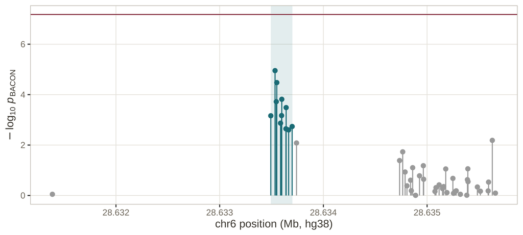

Figure 3: The detected DMR at chr6:28.63 Mb (hg38, Zhou coordinates). Each stem is one CpG within 2.5 kb of the region; the eleven inside the shaded window (teal) are the region comb-p reports, and all eleven are less methylated in cases. Every one sits far below the single-CpG genome-wide threshold (plum line, −log₁₀ p = 7.2), yet together — because they are adjacent and move in the same direction — they reach Šidák-corrected p = 2.4 × 10⁻¹⁶. This power gain is the entire reason to do region-level analysis.

```r
library(data.table)
library(dplyr)
library(ggplot2)

# The strongest comb-p region, by Sidak-corrected p, from the file the command above wrote
lead <- fread("data/08_annotation/dmr/PTSD_dmr.regions-p.bed.gz", data.table = FALSE) %>%
  arrange(z_sidak_p) %>%
  slice_head(n = 1)
lead_chr <- lead[[1]]; lead_start <- lead$start; lead_end <- lead$end

# Every tested CpG within 2.5 kb of the region, with its BACON p-value and hg38 position
ann_loc <- readRDS("data/08_annotation/annotated.rds")
bonf_line <- -log10(0.05 / nrow(ann_loc))
loc <- ann_loc %>%
  filter(CpG_chrm == lead_chr &
         CpG_beg >= lead_start - 2500 & CpG_beg <= lead_end + 2500) %>%
  mutate(in_region = CpG_beg >= lead_start & CpG_beg <= lead_end)

ggplot(loc, aes(CpG_beg / 1e6, -log10(bacon.p), colour = in_region)) +
  annotate("rect", xmin = lead_start / 1e6, xmax = lead_end / 1e6,
           ymin = -Inf, ymax = Inf, fill = "#1A6B75", alpha = 0.12) +
  geom_segment(aes(xend = CpG_beg / 1e6, y = 0, yend = -log10(bacon.p))) +
  geom_point(size = 2) +
  geom_hline(yintercept = bonf_line, colour = "#8C3A4A") +
  scale_colour_manual(values = c(`TRUE` = "#1A6B75", `FALSE` = "gray60"), guide = "none") +
  labs(x = paste0(lead_chr, " position (Mb, hg38)"),
       y = expression(-log[10]~italic(p)[BACON]))
```

### `ENmix::combp`: the same method, but with R

`comb-p` is a Python command-line tool, which means an extra environment to install for one step of one chapter. If you would rather stay in R, **`ENmix::combp`** (Xu et al. 2021) implements the same Stouffer–Liptak–Kechris approach, and it takes the BED we just built with only a column rename. (The same package also offers `ipdmr` (Xu et al. 2020), the authors’ interval-p-value variant.)

**NoteWhat this section needs**

This section starts from `data/08_annotation/PTSD_ewas_annotated_results.bed`, written by the `make-bed` chunk above. If you did not run that chunk, fetch the published copy instead:

```
Terminal
```

```bash
./get_data.sh H_annotation
```

```r
# ENmix's R implementation of the comb-p algorithm. The Python comb-p it is
# compared against below lives in `envs/combp.yml`.
library(ENmix)

bed <- data.table::fread("data/08_annotation/PTSD_ewas_annotated_results.bed",
                         data.table = FALSE)   # ENmix wants a plain data.frame
# ENmix expects its own column names, in this order: chr, start, end, p, probe
bed <- bed %>%
  rename(chr = `#chrom`, p = pvals, probe = cpgid) %>%
  mutate(chr = as.character(chr))

combp(data = bed,
      dist.cutoff = 750,           # must exceed bin.size (see the warning below)
      bin.size    = 310,           # ACF bin width
      seed        = 1e-4,          # FDR threshold for seeding a region
      nCores      = 4,
      region_plot = FALSE, mht_plot = FALSE)
```

```
P value correlations:
      bin         acf
0.cor 310 0.041181986
1.cor 620 0.015512545
2.cor 750 0.005473749
Number of DMRs identified:   9
```

```r
# combp() always writes resu_combp.csv into the working directory; move it
# alongside the other chapter 08 outputs
file.rename("resu_combp.csv", "data/08_annotation/08_enmix_combp.csv")
```

```
[1] TRUE
```

```r
enmix <- data.table::fread("data/08_annotation/08_enmix_combp.csv", data.table = FALSE)
cat("ENmix regions:", nrow(enmix), "| Sidak < 0.05:", sum(enmix$sidak < 0.05), "\n")
```

```
ENmix regions: 9 | Sidak < 0.05: 7
```

```r
# the region with the smallest Sidak p
enmix %>%
  slice_min(sidak, n = 1) %>%
  select(chr, start, end, nprobe, sidak)
```

| chr | start | end | nprobe | sidak |
| --- | --- | --- | --- | --- |
| chr6 | 28633494 | 28633743 | 12 | 0 |

It runs in about a minute on our 756,234-row BED and finds the same lead region: a 12-CpG DMR at **chr6:28,633,494–28,633,743**, the MHC-proximal locus command-line comb-p reports as 11 CpGs at chr6:28,633,493–28,633,701. The probe lists overlap almost completely; ENmix extends the region by one CpG (`cg12763978`) at the 3′ end.

**WarningTwo ways this differs from the command-line tool:**

**`bin.size` must be smaller than `dist.cutoff`.** ENmix builds its autocorrelation bins by `seq(bin.size, dist.cutoff, bin.size)`, so calling it with the shipped command-line settings (`--dist 200` with the default `bin.size = 310`) fails with `wrong sign in 'by' argument` rather than a message naming the problem. The `dist.cutoff = 750` above is chosen to exceed the default bin width.

**The two implementations do not return the same region count.** With the settings above ENmix reports **9** candidate regions of which **7** clear Šidák < 0.05, where command-line comb-p at `--dist 200 --seed 1e-4` reports **2** candidates of which **1** clears Šidák. Both single out the same chr6 locus as by far the strongest — ENmix calls 12 CpGs there against comb-p’s 11 — but ENmix is much more permissive about everything else. Some of that is the wider `dist.cutoff`, and some is that ENmix describes itself as a *modified* comb-p. Treat it as an R-native implementation of the same idea. Either method is okay, just make sure to report which one you used and its parameters.

The DMR numbers in this chapter come from the command-line tool at the parameters shown above, which is what chapter 07’s pipeline invokes.

### DMRcate: the line-level alternative

If you are using DMRcate, it operates on the M-value matrix directly:

```
Generic example, do not run
```

```r
# Schematic only: `M` and `design` are yours to supply. This chapter does not run
# DMRcate: it needs the full M-value matrix and the chapter 06 design in memory,
# and the pipeline's stratified route has no single design matrix to hand it.
library(DMRcate)
# M = CpG x sample matrix; design = model.matrix(~ PTSD + sex + age + cellcounts + SVs)
myannotation <- cpg.annotate("array", M, arraytype = "EPICv1",
                             analysis.type = "differential",
                             design = design, coef = "PTSD")
dmrs <- dmrcate(myannotation, lambda = 1000, C = 2)   # Gaussian-kernel smoothing
results.ranges <- extractRanges(dmrs, genome = "hg19")  # EPICv1 annotation is hg19,
                                                          # unlike this chapter's hg38 regions
```

Note what it requires that comb-p does not: the full `M` matrix in memory and a single `design`/`coef`. If your EWAS was residualized or meta-analyzed, you cannot express it as one `coef` here.

### Annotating the DMRs

Once regions exist, the pipeline’s `dmr_annotation.R` maps each DMR back to genes and islands by overlapping its coordinates against three UCSC **hg38** tables: **refGene**, **cpgIslandExt**, and the **HGNC** gene track. The chunk below downloads the same three from UCSC. The DMR’s constituent CpGs are looked up by coordinate in the Part 1 annotation table (`annotated.rds`), so each region carries its probe list and direction of effect. The overlap is a coordinate join — `bedtools intersect` in the pipeline, or `GenomicRanges::findOverlaps()` if you are staying in R — with no modeling involved. We run it here for our one region, the eleven CpGs of the comb-p MHC region at **chr6:28,633,493–28,633,701**:

```r
library(GenomicRanges)   # GRanges(), IRanges(), overlapsAny(), nearest()
library(jsonlite)        # fromJSON(), for the UCSC API query below

# The comb-p DMR, in hg38: the region with the smallest Sidak-corrected p in the
# regions-p file the comb-p command above wrote
top_dmr <- fread("data/08_annotation/dmr/PTSD_dmr.regions-p.bed.gz", data.table = FALSE) %>%
  arrange(z_sidak_p) %>%
  slice_head(n = 1)
dmr <- GRanges(top_dmr[[1]], IRanges(top_dmr$start, top_dmr$end))

# The same three UCSC hg38 tables the pipeline's fetch_dmr_annotation_cache rule
# downloads. refGene and cpgIslandExt are plain gzipped tables, so fread() reads
# them straight from the UCSC download server.
ucsc <- "https://hgdownload.soe.ucsc.edu/goldenPath/hg38/database/"

# refGene: columns 3-6 are chrom, strand, txStart, txEnd; column 13 is the gene symbol
rg <- fread(paste0(ucsc, "refGene.txt.gz"), header = FALSE, select = c(3, 4, 5, 6, 13),
            col.names = c("chrom", "strand", "txStart", "txEnd", "gene"), data.table = FALSE)
refGene <- GRanges(rg$chrom, IRanges(rg$txStart + 1L, rg$txEnd),   # UCSC starts are 0-based
                   strand = rg$strand, gene = rg$gene)

# cpgIslandExt: columns 2-4 are chrom, chromStart, chromEnd
cgi <- fread(paste0(ucsc, "cpgIslandExt.txt.gz"), header = FALSE, select = 2:4,
             col.names = c("chrom", "chromStart", "chromEnd"), data.table = FALSE)
cpgIslands <- GRanges(cgi$chrom, IRanges(cgi$chromStart + 1L, cgi$chromEnd))

# The HGNC track is a bigBed (the pipeline converts it with bigBedToBed). R's
# bigBed reader cannot parse this file's colour column, so ask the UCSC API for
# the records overlapping the DMR instead (API coordinates are 0-based).
hgnc <- fromJSON(paste0("https://api.genome.ucsc.edu/getData/track?genome=hg38;track=hgnc;",
                        sprintf("chrom=%s;start=%d;end=%d", as.character(seqnames(dmr)),
                                start(dmr) - 1L, end(dmr))))$hgnc

# genes whose transcript lies within 5 kb of the DMR, and the nearest one on each side
near_ref <- refGene[overlapsAny(refGene, dmr + 5000)]
lower    <- refGene[follow(dmr, refGene, ignore.strand = TRUE)]
higher   <- refGene[precede(dmr, refGene, ignore.strand = TRUE)]
length(near_ref)
```

```
[1] 0
```

```r
data.frame(side = c("lower coordinate", "higher coordinate"),
           gene = c(lower$gene, higher$gene),
           distance_bp = c(distance(dmr, lower), distance(dmr, higher)))
```

| side | gene | distance_bp |
| --- | --- | --- |
| lower coordinate | ZBED9 | 17315 |
| higher coordinate | LINC00533 | 14584 |

```r
hgnc[, c("symbol", "geneName", "locus_type")]
```

|  | symbol | geneName | locus_type |
| --- | --- | --- | --- |
| 1 | COX8CP1 | COX8C pseudogene 1 | pseudogene |

```r
# nearest CpG island: within 2 kb counts as a shore
isl <- cpgIslands[nearest(dmr, cpgIslands)]
distance(dmr, isl)
```

```
[1] 1375
```

This is a prime example region because **the three annotation sources disagree**, and the pipeline’s default gene table is the one that comes up empty. While often the sources do agree, it is not uncommon for annotation disagreements to occur:

```r
# One row per annotation source: what each names for the DMR. Rows one and two
# come from the UCSC queries in the chunk above; row three from the GENCODE v41
# annotation built in Part 1 (annotated.rds).
ann <- readRDS("data/08_annotation/annotated.rds")
# the region's CpGs by coordinate, not by a pasted probe list, so the region
# definition lives in one place
reg <- ann %>%
  filter(CpG_chrm == as.character(seqnames(dmr)) &
         CpG_beg >= start(dmr) & CpG_beg <= end(dmr)) %>%
  arrange(CpG_beg)
stopifnot(nrow(reg) == top_dmr$n_probes)   # the count comb-p reported; fail loudly if the map changed

# every gencode v41 gene the eleven probes are assigned to, de-duplicated
gencode_genes <- paste(sort(unique(unlist(strsplit(reg$genesUniq, ";")))),
                       collapse = ", ")

# check.names = FALSE keeps the space in "Annotation source"
dmr_src <- data.frame(check.names = FALSE,
  `Annotation source` = c("UCSC refGene (pipeline default gene table)",
                          "UCSC HGNC track",
                          "Zhou GENCODE v41 (our probe-level annotation)"),
  names = c(
    if (length(near_ref) == 0)
      sprintf("nothing within \u00b15 kb (nearest %s ~%.0f kb, %s ~%.0f kb)",
              lower$gene, distance(dmr, lower) / 1000, higher$gene, distance(dmr, higher) / 1000)
    else paste(unique(near_ref$gene), collapse = ", "),
    paste0(hgnc$symbol, " (", hgnc$geneName, ", directly overlapping)"),
    paste0(gencode_genes, " (promoter-associated, non-coding)")))
# the second column is labelled with the region's own hg38 coordinates
region_label <- sprintf("What it names for %s:%s\u2013%s", as.character(seqnames(dmr)),
                        formatC(start(dmr), big.mark = ",", format = "d"),
                        formatC(end(dmr),   big.mark = ",", format = "d"))
dmr_src <- dmr_src %>% rename_with(function(old) region_label, .cols = names)
fwrite(dmr_src, "data/08_annotation/dmr_source_comparison.csv")
```

```r
# written by the `dmr-sources-derive` chunk above
knitr::kable(fread("data/08_annotation/dmr_source_comparison.csv", data.table = FALSE),
  caption = "Three hg38 gene annotations, three answers for the same DMR. refGene — the pipeline's default `gene_table` — names nothing nearby; the region only acquires a label from the pseudogene track or from GENCODE.")
```

Three hg38 gene annotations, three answers for the same DMR. refGene — the pipeline’s default `gene_table` — names nothing nearby; the region only acquires a label from the pseudogene track or from GENCODE.

| Annotation source | What it names for chr6:28,633,493–28,633,701 |
| --- | --- |
| UCSC refGene (pipeline default gene table) | nothing within ±5 kb (nearest ZBED9 ~17 kb, LINC00533 ~15 kb) |
| UCSC HGNC track | COX8CP1 (COX8C pseudogene 1, directly overlapping) |
| Zhou GENCODE v41 (our probe-level annotation) | ENSG00000271440, ENSG00000287279 (promoter-associated, non-coding) |

refGene is a curated set of well-supported transcripts, so a DMR sitting in a gene-poor stretch of the MHC returns nothing within 5 kb — the nearest curated genes (ZBED9, LINC00533) are >14 kb away. The HGNC BigBed, which includes pseudogenes and genes from difficult to map regions, overlaps **COX8CP1** directly, and our probe-level GENCODE v41 annotation assigns the CpGs to two non-coding transcripts as **promoter** hits. None of these is “wrong”; they reflect different inclusion criteria. The lesson for a DMR walkthrough is to **read the coordinates, not just the gene symbol**: an empty `gene_table` overlap does not mean the region is intergenic junk — here it is a CpG-island shore over a pseudogene in an immune-gene-dense locus, exactly the kind of place methylation differences cluster. Our eleven CpGs, all hypomethylated in cases, look like this:

```r
# The eleven-row table rendered below, and the fuller per-CpG file that backs
# it. Both come from `reg` — the region's CpGs in the Part 1 annotation layer,
# built in the chunk above.
disp <- reg %>%
  mutate(
    `hg38 position (chr6)` = formatC(CpG_beg, big.mark = ",", format = "d"),
    # the annotation layer's label is "Promoter (±1.5 kb TSS)";
    # trim the parenthetical so the column stays narrow
    `GENCODE feature` = sub(" \\(.*", "", feature),
    # β difference on the 0-1 scale: -0.022 reads as 2.2 points hypo
    `Δβ (case − control)` = round(delta_beta, 3),
    `BACON p` = signif(bacon.p, 3)) %>%
  select(CpG = probe, `hg38 position (chr6)`, `GENCODE feature`,
         `CGI context` = island, `Δβ (case − control)`, `BACON p`)
fwrite(disp, "data/08_annotation/dmr_cpg_display.csv")

# the same eleven CpGs with everything the annotation layer knows about them,
# including the transcript list the display table has no room for
full <- reg %>%
  mutate(delta_beta = round(delta_beta, 4),
         bacon.es   = round(bacon.es, 3),
         bacon.p    = signif(bacon.p, 3)) %>%
  select(probe, CpG_beg, CpG_end, genesUniq, transcriptTypes, distTSS,
         feature, island, BIOS_eQTM_genes, delta_beta, bacon.es, bacon.p)
fwrite(full, "data/08_annotation/dmr_cpg_annotation.csv")
```

```r
# written by the `dmr-cpgs-derive` chunk above
knitr::kable(fread("data/08_annotation/dmr_cpg_display.csv", data.table = FALSE),
  caption = "The eleven CpGs of the DMR. All fall in the same CpG-island north shore and are hypomethylated in PTSD cases — Δβ between −2.2 and −5.8 percentage points, every one in the same direction. That coherence is what makes a region call meaningful; none of the eleven individual BACON p-values comes close to genome-wide significance.")
```

The eleven CpGs of the DMR. All fall in the same CpG-island north shore and are hypomethylated in PTSD cases — Δβ between −2.2 and −5.8 percentage points, every one in the same direction. That coherence is what makes a region call meaningful; none of the eleven individual BACON p-values comes close to genome-wide significance.

| CpG | hg38 position (chr6) | GENCODE feature | CGI context | Δβ (case − control) | BACON p |
| --- | --- | --- | --- | --- | --- |
| cg07017437 | 28,633,493 | Promoter | N_Shore | -0.022 | 6.89e-04 |
| cg25653641 | 28,633,534 | Promoter | N_Shore | -0.058 | 1.12e-05 |
| cg22572476 | 28,633,546 | Promoter | N_Shore | -0.058 | 1.90e-04 |
| cg19488431 | 28,633,551 | Promoter | N_Shore | -0.053 | 3.32e-05 |
| cg27535677 | 28,633,587 | Promoter | N_Shore | -0.036 | 1.36e-03 |
| cg22497095 | 28,633,597 | Promoter | N_Shore | -0.043 | 6.76e-04 |
| cg26865747 | 28,633,599 | Promoter | N_Shore | -0.044 | 1.53e-04 |
| cg03759229 | 28,633,639 | Promoter | N_Shore | -0.040 | 2.27e-03 |
| cg13565129 | 28,633,641 | Promoter | N_Shore | -0.043 | 3.26e-04 |
| cg14654363 | 28,633,665 | Promoter | N_Shore | -0.027 | 2.51e-03 |
| cg00990380 | 28,633,699 | Promoter | N_Shore | -0.026 | 1.84e-03 |

### From regions to pathways: `goregion`

The gene-set tools in Part 3 take a list of *CpGs*. When your unit of discovery is a **region**, `missMethyl::goregion` (Phipson et al. 2016) is the region-level analog of `gometh`: give it a `GRanges` of your DMRs and it maps each region to the CpGs it contains, collapses those to genes, and runs the same probe-number-bias-corrected GO/KEGG test. It is the natural way to ask “are my comb-p regions collectively enriched for a biological process?”

By default `goregion` (like `gometh` in Part 3) uses **Illumina’s hg19** annotation package to decide which CpGs fall in a region and which genes they belong to, whereas the rest of this chapter, including the comb-p region itself, uses Wanding Zhou’s **hg38** resources. Both functions accept an annotation of your own through their `anno` argument, so we build one from the Zhou GENCODE v41 manifest read in Part 1. missMethyl expects the column names of Illumina’s package, so the Zhou columns are renamed to match:

```r
# One row per CpG probe with hg38 coordinates. `v41` is the Zhou manifest read in Part 1.
z <- v41 %>% filter(grepl("^cg", probeID) & !is.na(CpG_beg))
genes <- if_else(is.na(z$genesUniq), "", z$genesUniq)     # ';'-separated gene names
zhou_anno <- S4Vectors::DataFrame(
  Name   = z$probeID,
  chr    = z$CpG_chrm,
  pos    = z$CpG_beg + 1L,                                # Zhou's starts are 0-based
  strand = if_else(is.na(z$probe_strand), "*", z$probe_strand),
  UCSC_RefGene_Name = genes,
  # missMethyl wants one gene-region label per gene. It only uses them when you
  # restrict the test to particular regions (genomic.features), which we do not,
  # so a placeholder label is enough.
  UCSC_RefGene_Group = vapply(strsplit(genes, ";"),
                              function(g) paste(rep("gene", length(g)), collapse = ";"), ""),
  row.names = z$probeID)
nrow(zhou_anno)
```

```
[1] 862927
```

```r
library(missMethyl)
# The DMR from its eleven CpGs' hg38 positions. `reg` is the region's rows of the
# Part 1 annotation, built in the dmr-sources-derive chunk above.
dmr_gr <- GenomicRanges::reduce(GenomicRanges::GRanges(
  reg$CpG_chrm, IRanges::IRanges(reg$CpG_beg + 1L, width = 2)))

# all.cpg is the tested universe: `tt` is the chapter 06 top-table read in by the
# make-bed chunk above
gr_go <- goregion(dmr_gr, all.cpg = tt$probe, collection = "GO",
                  array.type = "EPIC", anno = zhou_anno)
```

```
Error in `getMappedEntrezIDs()`:
! There are no genes annotated to the significant CpGs
```

Run on our single MHC DMR, `goregion` **returns an error**: *“There are no genes annotated to the significant CpGs.”*. In Zhou’s GENCODE v41 annotation the region’s CpGs are assigned only to two unnamed non-coding genes, which have Ensembl IDs but no gene symbol. missMethyl can only test genes it can match to an Entrez ID, so there is nothing to map to a GO term. (Illumina’s hg19 annotation gives the same error for this region.) Two lessons fall out of this:

1. **Enrichment inherits the annotation’s gene assignments.** If the annotation maps a region to no gene, a gene-centric lens for pathway enrichment will not have anything to query or report.
2. **`goregion` needs *many* regions to be meaningful.** One region is never an “enrichment”; a real DMR analysis feeds it the dozens-to-hundreds of regions comb-p or DMRcate returns genome-wide. We show the mechanism here even though it doesn’t produce a meaningful result so the call is in your toolkit.

## Part 3 — Pathway, trait, and functional enrichment

Annotation names the genes near your hits; **enrichment** asks whether that gene list is *collectively* over-represented in any biological process, pathway, or previously reported trait. This is where an EWAS stops being a list of CpGs and starts pointing at mechanism. Two things make methylation enrichment different from the gene-expression version you may know:

1. **Probe-number bias.** Genes are not covered evenly on the array — a large gene like *PRKG1* carries hundreds of probes, a small one only a handful. A naive test that treats “gene has ≥1 significant CpG” as a hit will therefore flag long, densely-tiled genes purely because they had more chances to be picked. Enrichment for methylation **must** correct for the number of probes per gene.
2. **Multiple CpGs map to one gene**, and CpGs in intergenic space map to none. The tool has to collapse probes to genes sensibly before testing.

### missMethyl `gometh`: the reproducible, bias-corrected default

`missMethyl::gometh()` (and its generic `gsameth()` for custom gene sets) is the field-standard R implementation. It maps your significant CpGs to genes, models the per-gene probe count as the bias covariate, and runs a corrected hypergeometric test against GO or KEGG (Phipson et al. 2016). By default it assigns CpGs to genes with Illumina’s **hg19** EPIC annotation package; passing `anno = zhou_anno` makes it use the same Zhou **hg38** GENCODE v41 genes as the rest of this chapter. Enrichment has not yet been added to the Snakemake pipeline, but will in a future release.

Normally you would run GO/KEGG enrichment only on the CpGs that reach epigenome-wide significance. The EWAS of this subset identified none, which leaves nothing to test, so here we use the top 1,000 CpGs by BACON *p*-value as our “significant set”.

```r
# The Wallenius test runs over every GO term, so this takes about a minute. The
# RDS written at the end is what the comparison table further down reads.
# `zhou_anno` is the hg38 annotation built in Part 2's zhou-anno chunk.
library(missMethyl)
library(dplyr)
tt     <- data.table::fread("data/06_ewas_bacon_toptable.csv.gz", data.table = FALSE)
all.cpg <- tt$probe                          # tested universe = every CpG you analyzed
sig.cpg <- tt %>%                             # your significant set
  arrange(bacon.p) %>%
  slice_head(n = 1000) %>%
  pull(probe)

# GO enrichment, corrected for probes-per-gene. array.type matches your array.
# anno = zhou_anno: genes from Zhou's hg38 GENCODE v41, not Illumina's hg19 default
go <- gometh(sig.cpg = sig.cpg, all.cpg = all.cpg,
             collection = "GO", array.type = "EPIC", anno = zhou_anno)
go <- go[order(go$P.DE), ]

# KEGG is a one-word change
kegg <- gometh(sig.cpg = sig.cpg, all.cpg = all.cpg,
               collection = "KEGG", array.type = "EPIC", anno = zhou_anno)
kegg <- kegg[order(kegg$P.DE), ]

# Both collections in one object. The method comparison below reads `kegg` back
# out of it, and keeping `go` alongside means the GO panel of the figure can be
# redrawn without re-running the test.
saveRDS(list(go = go, kegg = kegg), "data/08_annotation/08_gometh.rds")
```

Two arguments carry all the weight. `all.cpg` is the **full tested set** — it must be every CpG that survived *your* QC and filtering, not the whole array manifest, or the test is biased toward whatever your pipeline happened to remove. Defining “significant” (`sig.cpg`) by a fixed top-*N* (here 1,000) is a teaching compromise, as noted above.

Run on our teaching subset, the corrected results are:

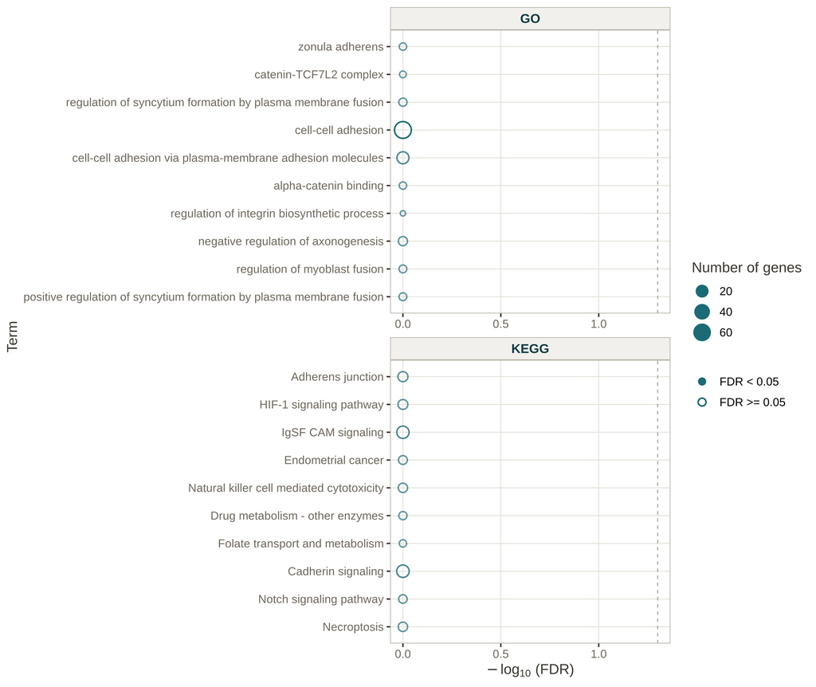

Figure 4: GO and KEGG enrichment of the top 1,000 CpGs by BACON *p*, computed with `gometh` on Zhou’s hg38 gene assignments (probe-number–corrected hypergeometric test). The ten leading terms by nominal *P* in each collection, each collection corrected within itself and on its own x axis. Point size and shade show how many genes from the top set fall in the term; solid points pass FDR < 0.05 (dashed line) and hollow points do not. **Nothing survives FDR at n = 86**, the expected outcome when no CpG reaches epigenome-wide significance.

```r
# Drawn the same way as the EWAS pipeline's pathway plot (scripts/plot_enrichment.R
# in github.com/krferrier/EWAS), so this figure and the pipeline's look alike.
library(ggplot2)
library(dplyr)

fdr_threshold <- 0.05
# The ten leading terms by nominal p within each collection: GO and KEGG are
# corrected separately, so a pooled top ten would be all GO.
top_terms <- bind_rows(
  go %>%
    arrange(P.DE) %>%
    slice_head(n = 10) %>%
    mutate(collection = "GO") %>%
    select(collection, term = TERM, DE, FDR),
  kegg %>%
    arrange(P.DE) %>%
    slice_head(n = 10) %>%
    mutate(collection = "KEGG") %>%
    select(collection, term = Description, DE, FDR))
top_terms <- top_terms %>%
  mutate(neg_log10_fdr = -log10(FDR),
         signif = factor(FDR < fdr_threshold, levels = c(TRUE, FALSE)),
         # Order each panel by -log10(FDR), then nominal p for ties, so the leading term is on top
         term = make.unique(as.character(term), sep = " "),
         term = factor(term, levels = rev(term)))

# An invisible point carrying both significance levels, so the legend always
# explains solid against hollow even when every point falls on one side.
key <- data.frame(neg_log10_fdr = top_terms$neg_log10_fdr[1], term = top_terms$term[1],
                  collection = top_terms$collection[1],
                  signif = factor(c(TRUE, FALSE), levels = c(TRUE, FALSE)))

ggplot(top_terms, aes(x = neg_log10_fdr, y = term, size = DE, alpha = DE)) +
  geom_vline(xintercept = -log10(fdr_threshold), linetype = "dashed",
             colour = "grey55", linewidth = 0.3) +
  geom_point(aes(shape = signif), colour = "#1A6B75", stroke = 0.9) +
  geom_point(data = key, aes(x = neg_log10_fdr, y = term, shape = signif),
             size = 0, alpha = 0, inherit.aes = FALSE) +
  scale_shape_manual(values = c(`TRUE` = 19, `FALSE` = 1), limits = c("TRUE", "FALSE"),
                     labels = c(sprintf("FDR < %g", fdr_threshold),
                                sprintf("FDR >= %g", fdr_threshold)),
                     drop = FALSE, name = NULL) +
  scale_alpha(range = c(0.65, 1), guide = "none") +
  scale_size(range = c(1.5, 6), name = "Number of genes") +
  guides(shape = guide_legend(override.aes = list(size = 2.5, alpha = 1, colour = "#1A6B75"))) +
  # Each collection gets its own x axis, because they are corrected separately
  facet_wrap(~ collection, ncol = 1, scales = "free") +
  labs(x = expression(-log[10] ~ "(FDR)"), y = "Term")
```

The top nominal terms here are zonula adherens (GO:0005915, *P* = 1.6 × 10⁻³), the catenin-TCF7L2 complex, regulation of syncytium formation by plasma membrane fusion, and cell-cell adhesion. It is easy to read a cell-adhesion theme into that list, but there is **no term at FDR < 0.05** in either collection. The smallest FDR in both GO and KEGG is 1 (the top KEGG pathway is Adherens junction, nominal *P* = 0.0032). This is exactly what enrichment of a **null** gene list should look like. Reading *this* result as “PTSD methylation remodels adherens junctions” would be false: with 1,000 arbitrarily-chosen CpGs, a handful of small gene sets always reach nominal *p* < 0.01 by chance — note that the leading GO term has only 8 genes in it, 4 of which the top set touched.

### `methylGSA`: the same question, a different bias model

`gometh` is not the only way to correct for the probe-number bias, and the choice of correction can change the outcome. **`methylGSA`** (Ren and Kuan 2019) offers two alternatives to `gometh`’s Wallenius hypergeometric test. By default it uses Illumina’s **hg19** annotation package; its `FullAnnot` argument takes a CpG-to-gene table of your own, so we give it the same Zhou **hg38** GENCODE v41 genes `gometh` used. The three methods below then differ in their statistics, not their gene assignments:

- **`methylglm`** models each gene set with a **logistic regression** in which the per-gene number of probes enters as a covariate — a continuous adjustment rather than a weighted urn, and it takes the *whole* ranked p-value vector, not a hard top-*N* cutoff.
- **`methylRRA`** aggregates the CpG p-values to a per-gene score by **robust rank aggregation**, then runs either an over-representation test or a **GSEA**-style rank test — no significance cutoff at all.

**NoteThis section runs in its own environment**

On the R-only route, `BiocManager` installs `methylGSA` alongside everything else and there is nothing to do. Conda users need `envs/methylgsa.yml` (`conda env create -f envs/methylgsa.yml`) because bioconda’s newest `methylGSA` build is for an older R than the rest of the stack. Nothing is shared at run time: the only input below is the BACON top-table CSV written by chapter 06. Copy the chunk into a script and run it from the `tutorial/` folder with `conda run -n methylgsa Rscript <script>`; it writes the three files the comparison chunks below read. Those three files are also committed to the repository, so the rest of the section runs without this step.

```r
library(methylGSA)
library(data.table)   # fread()/fwrite()
library(dplyr)        # filter(), select(), arrange() and the other table verbs

# This chunk runs in its own R session, so it reads the Zhou v41 manifest itself.
# prepareAnnot() wants one row per CpG: the probe ID and its ';'-separated genes.
v41 <- fread(paste0("https://raw.githubusercontent.com/zhou-lab/InfiniumAnnotationData/",
                    "6d176d6e7e56465403d4478a09fe11b983eeb721/Anno/EPIC/",
                    "EPIC.hg38.manifest.gencode.v41.tsv.gz"), data.table = FALSE)
cpg2gene  <- v41 %>%
  filter(grepl("^cg", probeID) & !is.na(genesUniq) & genesUniq != "") %>%
  select(CpG = probeID, gene = genesUniq)
FullAnnot <- prepareAnnot(cpg2gene)

tt <- data.table::fread("data/06_ewas_bacon_toptable.csv.gz", data.table = FALSE)
pv <- setNames(tt$bacon.p, tt$probe)          # NAMED vector: names = CpG IDs

# logistic-regression enrichment (bias covariate = probes per gene)
mglm <- methylglm(cpg.pval = pv, FullAnnot = FullAnnot,
                  GS.type = "KEGG", minsize = 10, maxsize = 500)

# GSEA on rank-aggregated per-gene scores. Its p-values come from random
# permutations, so fix the seed to get the same table on every run.
set.seed(20260922)
mrra <- methylRRA(cpg.pval = pv, FullAnnot = FullAnnot, method = "GSEA",
                  GS.type = "KEGG", minsize = 10, maxsize = 500)

# methylGSA looks pathway names up through clusterProfiler, whose older releases
# no longer get human pathway IDs back from KEGG, leaving Description empty. Fill
# any gaps from KEGG's own list of human pathways.
kegg_names <- fread("https://rest.kegg.jp/list/pathway/hsa", header = FALSE,
                    col.names = c("id", "name"), data.table = FALSE) %>%
  mutate(id = sub("^hsa", "", id), name = sub(" - Homo sapiens \\(human\\)$", "", name))
fill_names <- function(res) {
  miss <- is.na(res$Description)
  res$Description[miss] <- kegg_names$name[match(res$ID[miss], kegg_names$id)]
  res
}
mglm <- fill_names(mglm)
mrra <- fill_names(mrra)

# Export results
saveRDS(list(methylglm = mglm, methylRRA = mrra),
        "data/08_annotation/08_methylgsa.rds")
glm_top <- mglm %>%
  arrange(pvalue) %>%
  slice_head(n = 10) %>%
  mutate(Method = "methylglm") %>%
  select(Method, KEGG = ID, Pathway = Description, Size, pvalue, padj)
fwrite(glm_top, "data/08_annotation/08_methylgsa_glm_top.csv")
rra_top <- mrra %>%
  arrange(pvalue) %>%
  slice_head(n = 5) %>%
  mutate(Method = "methylRRA-GSEA") %>%
  select(Method, KEGG = ID, Pathway = Description, Size, NES, pvalue, padj)
fwrite(rra_top, "data/08_annotation/08_methylgsa_rra_top.csv")
```

We ran all three tools on the **same** BACON top-table, against the **same** KEGG collection, and recorded both how many pathways each calls significant at FDR < 0.05 and what each one puts at the top:

```r
# The comparison table rendered below, rebuilt from the three result files the
# two chunks above write rather than typed out by hand.
g  <- readRDS("data/08_annotation/08_gometh.rds")
# gometh keeps the KEGG ids in the row names; move them into an ID column
kg <- g$kegg %>%
  rownames_to_column("ID") %>%
  arrange(P.DE)
# KEGG ids are zero-padded ("04140"), so they must not be read as integers.
gl <- fread("data/08_annotation/08_methylgsa_glm_top.csv", colClasses = c(KEGG = "character"),
            data.table = FALSE)
rr <- fread("data/08_annotation/08_methylgsa_rra_top.csv", colClasses = c(KEGG = "character"),
            data.table = FALSE)
mg <- readRDS("data/08_annotation/08_methylgsa.rds")   # full methylglm and methylRRA tables

# A misspelled column name returns NULL, which c() drops without warning; the
# two remaining names would then be recycled down three rows. Check first.
leaders <- c(kg$Description[1], gl$Pathway[1], rr$Pathway[1])
stopifnot(length(leaders) == 3L)

# check.names = FALSE keeps the spaces and symbols in the column names
cmp <- data.frame(check.names = FALSE,
  Method = c("gometh (Wallenius hypergeometric)",
             "methylglm (logistic regression)",
             "methylRRA-GSEA (rank aggregation)"),
  Input  = c("top 1,000 CpGs vs universe",
             "full named p-value vector",
             "full named p-value vector"),
  `Bias model` = c("probes per gene (Wallenius)",
                   "probe count as covariate",
                   "gene-level RRA score"),
  # The two methylGSA top files hold only their top rows, so the significant
  # counts are taken from the full result tables in 08_methylgsa.rds.
  `KEGG FDR<0.05` = c(sum(kg$FDR < 0.05),
                      sum(mg$methylglm$padj < 0.05, na.rm = TRUE),
                      sum(mg$methylRRA$padj < 0.05, na.rm = TRUE)),
  `Top KEGG pathway` = leaders,
  `Its nominal p` = signif(c(kg$P.DE[1], gl$pvalue[1], rr$pvalue[1]), 3),
  `Its FDR`       = signif(c(kg$FDR[1],  gl$padj[1],   rr$padj[1]),   3)
)
fwrite(cmp, "data/08_annotation/08_gsa_method_comparison.csv")
```

```r
# written by the `gsa-compare-derive` chunk above
knitr::kable(fread("data/08_annotation/08_gsa_method_comparison.csv", data.table = FALSE),
  caption = "Three probe-bias corrections, one dataset, one gene annotation (Zhou hg38 GENCODE v41). gometh and methylglm return no KEGG pathway at FDR < 0.05; methylRRA-GSEA returns eight. Each nominates a different pathway as its leader — the ranking, not just the count, depends on the bias model and the input convention.")
```

Three probe-bias corrections, one dataset, one gene annotation (Zhou hg38 GENCODE v41). gometh and methylglm return no KEGG pathway at FDR < 0.05; methylRRA-GSEA returns eight. Each nominates a different pathway as its leader — the ranking, not just the count, depends on the bias model and the input convention.

| Method | Input | Bias model | KEGG FDR<0.05 | Top KEGG pathway | Its nominal p | Its FDR |
| --- | --- | --- | --- | --- | --- | --- |
| gometh (Wallenius hypergeometric) | top 1,000 CpGs vs universe | probes per gene (Wallenius) | 0 | Adherens junction | 0.003180 | 1.0000 |
| methylglm (logistic regression) | full named p-value vector | probe count as covariate | 0 | Amoebiasis | 0.003400 | 0.6250 |
| methylRRA-GSEA (rank aggregation) | full named p-value vector | gene-level RRA score | 8 | Non-small cell lung cancer | 0.000201 | 0.0263 |

The three tools use the same genes and the same pathways, and still disagree. `gometh` and `methylglm` find nothing at FDR < 0.05, with smallest FDRs of 1 and 0.63, while `methylRRA`-GSEA reports **eight significant pathways**, led by Non-small cell lung cancer and Pyruvate metabolism (both FDR = 0.026). Each also nominates a different leader (Adherens junction, Amoebiasis, Non-small cell lung cancer).

Treat those eight pathways methylRRA identifies with caution. `methylRRA`’s GSEA mode uses the full ranking and no cutoff, so it is the most sensitive of the three *and* the most prone to calling pathways in a dataset where no single CpG reaches epigenome-wide significance. Its p-values also come from random permutations: the chunk above fixes the seed so the table is the same on every render, but without the seed, two otherwise identical runs called eleven and nine pathways significant. A result that changes with the random seed is not one to write up on its own; it would need to be confirmed with a different method or in another cohort.

```r
# written by the `methylgsa` chunk above
# KEGG ids are zero-padded ("05223"), so read them as text
rra <- fread("data/08_annotation/08_methylgsa_rra_top.csv", colClasses = c(KEGG = "character"),
             data.table = FALSE)
# NES is only present when the file came from a GSEA run, so take the columns
# that are there instead of failing the render on a missing one
rra_cols <- intersect(c("KEGG", "Pathway", "Size", "NES", "pvalue", "padj"), names(rra))
knitr::kable(rra %>% select(all_of(rra_cols)),
  digits = 4,
  caption = "The five top-ranked methylRRA-GSEA KEGG pathways. All five pass FDR < 0.05 (eight pathways do in total) on a dataset with no epigenome-wide signal, which is the sensitivity/specificity trade-off of a cutoff-free rank test made concrete.")
```

The five top-ranked methylRRA-GSEA KEGG pathways. All five pass FDR < 0.05 (eight pathways do in total) on a dataset with no epigenome-wide signal, which is the sensitivity/specificity trade-off of a cutoff-free rank test made concrete.

| KEGG | Pathway | Size | NES | pvalue | padj |
| --- | --- | --- | --- | --- | --- |
| 05223 | Non-small cell lung cancer | 50 | 1.2638 | 2e-04 | 0.0263 |
| 00620 | Pyruvate metabolism | 36 | 1.2866 | 3e-04 | 0.0263 |
| 04666 | Fc gamma R-mediated phagosome formation | 82 | 1.1976 | 4e-04 | 0.0280 |
| 05142 | Chagas disease | 87 | 1.1641 | 6e-04 | 0.0307 |
| 05110 | Vibrio cholerae infection | 47 | 1.2597 | 7e-04 | 0.0307 |

**ImportantThe tool is a modeling choice, not a lookup**

Report the method **and** its settings, not just “KEGG enrichment.” A reviewer who reruns your CpGs through a different tool will get a different list, and that is expected — `gometh`, `methylglm`, and `methylRRA` encode different assumptions about how probe density biases the test. Pick one *a priori* (we default to `gometh` for its conservative, well-validated behavior), and if you report a second for sensitivity, say so and show both. Never run all three and present the one with the prettiest pathway.

### KnowYourCG (KYCG): CpG-centric enrichment on regulatory elements

`gometh` asks a **gene-set** question — it collapses your CpGs to genes and tests GO/KEGG. But methylation acts through *regulatory elements* — CpG islands, transcription-factor binding sites, chromatin states, histone marks — and collapsing to genes throws that resolution away. **KnowYourCG** (KYCG), part of Zhou’s `sesame`/`knowYourCG` ecosystem (Goldberg et al. 2025), keeps the CpG as the unit of analysis and tests your hit set directly against curated databases of these elements. It is the CpG-centric complement to `gometh`, not a replacement, and it comes from the same lab as the annotation we used in Part 1.

The knowledgebases are keyed by probe ID, so there are no coordinates to line up, but they were not all built on the same genome. The CpG-island knowledgebase is derived from the hg38 manifest’s `CGIposition` column (the same source as Part 1’s island context), while the chromatin-state knowledgebase comes from Roadmap chromHMM states annotated on hg19. The transcription-factor and histone-mark knowledgebases are hg38: they were built by intersecting ChIP-seq peaks from the Cistrome Data Browser with the array’s CpG coordinates (Goldberg et al. 2025), and Cistrome maps all human data to hg38 (Zheng et al. 2019).

```r
library(knowYourCG)
library(sesameData)
library(dplyr)

# Download the EPIC knowledgebases into the ExperimentHub cache. testEnrichment()
# stops with 'either not found or needs to be cached' until this has run once;
# after that it is a no-op.
kycgDataCache()
tt      <- data.table::fread("data/06_ewas_bacon_toptable.csv.gz", data.table = FALSE)
all.cpg <- tt$probe                              # universe = every CpG you tested
sig.cpg <- tt %>%                                 # your query set
  arrange(bacon.p) %>%
  slice_head(n = 1000) %>%
  pull(probe)

# What CpG-feature databases are available for this platform?
# ALWAYS list first: the catalog names carry datestamps and they change
# between releases. A wrong name fails at load time, not at test time.
listDBGroups("EPIC")           # EPIC knowledgebases: CGI, TFBS, chromHMM, HM, ...
```

| Title | Description | type |
| --- | --- | --- |
| KYCG.EPICv2.TFBS.20220921 | KYCG knowledgebase holding transcription factor binding sites | knowledgebase |
| KYCG.EPICv2.HM.20221013 | KYCG knowledgebase holding histone modifications | knowledgebase |
| KYCG.EPICv2.Mask.20230314 | KYCG knowledgebase holding technical masks | knowledgebase |
| KYCG.EPICv2.ABCompartment.20220911 | KYCG knowledgebase holding AB compartments | knowledgebase |
| KYCG.EPICv2.ImprintingDMR.20220818 | KYCG knowledgebase holding imprinting differentially methylated regions | knowledgebase |
| KYCG.EPICv2.ChromHMM.20220303 | KYCG knowledgebase holding consensus ChromHMM states | knowledgebase |
| KYCG.EPICv2.MetagenePC.20220911 | KYCG knowledgebase holding protein coding metagenes | knowledgebase |
| KYCG.EPICv2.CTCFbind.20220911 | KYCG knowledgebase holding CTCF binding sites | knowledgebase |
| KYCG.EPIC.CGI.20210713 | CpG island (Island, S_Shore, N_Shelf, N_Shore, S_Shelf) using CGIposition column in EPIC.hg38.manifest.CpGIsland.tsv.gz . | categorical |
| KYCG.EPIC.chromHMM.20211020 | chromHMM consensus from Roadmap, original ID: EPIC.hg19.REMC.chromHMM.tsv.gz | categorical |

[output cut: 9 more lines]

```r
# Cache the databases you want from ExperimentHub, then test.
dbs <- c("KYCG.EPIC.CGI.20210713",               # CpG-island relation
         "KYCG.EPIC.chromHMM.20211020",          # chromatin states
         "KYCG.EPIC.TFBSconsensus.20211013",     # TF binding sites
         "KYCG.EPIC.HMconsensus.20211013")       # histone marks
res <- testEnrichment(query = sig.cpg, databases = dbs,
                      universe = all.cpg, platform = "EPIC")
res <- res[order(res$FDR), ]

# All 863 tested features, one row each: the deposited result table, and the
# input to every KYCG number quoted below.
data.table::fwrite(res, "data/08_annotation/08_kycg_results.csv")
```

`testEnrichment` runs a Fisher test of your query CpGs against each database, using **your** tested set as the universe (the same universe discipline that matters for `gometh`). The databases are versioned knowledgebases pulled from ExperimentHub, so the run is reproducible.

The universe is all 756,251 tested CpGs and the query is the same top 1,000 used for `gometh`, tested against **863 features** across the four knowledgebases. That number matters for the interpretation below — the four databases are wildly different sizes.

knowYourCG applies the Benjamini–Hochberg correction **within each knowledgebase**, not across all 863 features at once. That is a choice with consequences: a feature in the five-row CpG-island knowledgebase is corrected against four others, while a transcription-factor feature is corrected against 782. Earlier releases of knowYourCG corrected across all 863; with that correction the same p-values give 2 significant features rather than 5, and the difference is the `H1.4`, `H3K9me2` and `8_ZNF/Rpts` results discussed below. Check which correction your version applies before you report a count.

On our teaching subset KYCG returns **5 features at FDR < 0.05** where `gometh` returned nothing. The two results are not directly comparable. They ask different questions: `gometh` collapses CpGs to genes and tests pathways, while KYCG keeps the CpG as the unit and tests which regulatory elements the CpGs fall in. Their annotations also differ: `gometh`’s gene assignments here come from Zhou’s hg38 GENCODE v41 manifest, whereas KYCG’s features come from Zhou’s knowledgebases, which are hg38 except for the hg19 chromatin states. The count of 5 also needs care, because KYCG’s feature sets are large and overlap heavily; the callout below works through what those 5 features do and do not show.

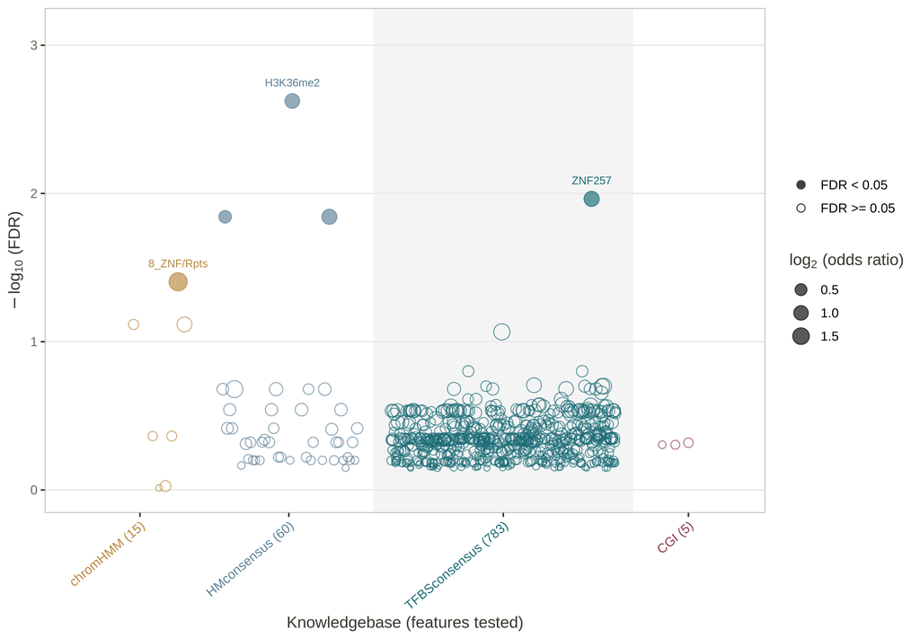

Figure 5: KYCG enrichment of the top 1,000 CpGs. Each knowledgebase gets its own block along the x axis (number of features tested in brackets), because FDR is corrected within each knowledgebase, not across them. Every over-represented feature (log₂ odds ratio > 0) is drawn, sized by its log₂ odds ratio: solid points pass FDR < 0.05, hollow points do not. The strongest significant feature in each knowledgebase is labelled.

```r
# Drawn the same way as the EWAS pipeline's feature plot (scripts/plot_enrichment.R
# in github.com/krferrier/EWAS), which follows knowYourCG's KYCG_plotEnrichAll.
library(ggplot2)
library(ggrepel)   # geom_text_repel(), labels that avoid the points
library(ggtext)    # element_markdown(), axis labels coloured to match their block
library(dplyr)

fdr_threshold <- 0.05
kd <- res %>%
  mutate(kb = sub("^KYCG[.]EPIC[.]", "", sub("[.][0-9]+$", "", group))) %>%
  filter(!is.na(FDR) & is.finite(estimate))

# Blocks in the pipeline's order: chromatin states and histone marks together,
# then protein binding, then gene context. Alternate groups are shaded.
kb_order <- c("chromHMM", "HMconsensus", "TFBSconsensus", "CGI")
kb_group <- c(chromHMM = 1, HMconsensus = 1, TFBSconsensus = 2, CGI = 3)
kb_cols  <- c(chromHMM = "#B8883E", HMconsensus = "#5B7F95",
              TFBSconsensus = "#1A6B75", CGI = "#8C3A4A")
kd <- kd %>%
  mutate(kb = factor(kb, levels = kb_order)) %>%
  arrange(kb, dbname)

# Each block's width grows with log(number of features), so the 783 TF binding
# sites do not swallow the axis and the 5 CpG-island features stay findable.
n_tested <- table(kd$kb)
kd <- kd %>%
  mutate(inc  = as.numeric((log(2 + n_tested) / n_tested)[as.character(kb)]),
         step = c(0, as.numeric(head(as.character(kb), -1) != tail(as.character(kb), -1))),
         xpos = cumsum(inc + step))

blocks <- kd %>%
  group_by(kb) %>%
  summarise(middle = mean(xpos), beg = min(xpos), end = max(xpos), n = n())
min_w <- 0.006 * diff(range(kd$xpos))
blocks <- blocks %>% mutate(half = pmax((end - beg) / 2, min_w))
pad <- min(diff(blocks$middle)) * 0.12
blocks <- blocks %>%
  mutate(rmin = middle - half - pad, rmax = middle + half + pad,
         grp = kb_group[as.character(kb)],
         lab = sprintf("<span style='color:%s'>%s (%d)</span>",
                       kb_cols[as.character(kb)], kb, n))
bands <- blocks %>%
  group_by(grp) %>%
  summarise(rmin = min(rmin), rmax = max(rmax)) %>%
  mutate(shade = grp %% 2 == 0)

# Only over-represented features are drawn: the test is one-sided, so a
# depleted feature carries no evidence either way.
pts <- kd %>%
  filter(estimate > 0) %>%
  mutate(y = -log10(FDR),
         signif = factor(FDR < fdr_threshold, levels = c(TRUE, FALSE)))
# The strongest significant feature in each knowledgebase gets a label;
# the labels are then listed strongest first
kb_labels <- pts %>%
  filter(signif == "TRUE") %>%
  group_by(kb) %>%
  slice_max(y, n = 1, with_ties = FALSE) %>%
  ungroup() %>%
  arrange(desc(y))
y_top <- max(3, max(pts$y) * 1.18)
key <- data.frame(xpos = pts$xpos[1], y = pts$y[1],
                  signif = factor(c(TRUE, FALSE), levels = c(TRUE, FALSE)))

ggplot(pts, aes(xpos, y)) +
  geom_rect(data = filter(bands, shade == TRUE), aes(xmin = rmin, xmax = rmax, ymin = -Inf, ymax = Inf),
            fill = "grey92", colour = NA, alpha = 0.55, inherit.aes = FALSE) +
  geom_point(aes(size = estimate, colour = kb, shape = signif), alpha = 0.65) +
  geom_point(data = key, aes(xpos, y, shape = signif), size = 0, alpha = 0, inherit.aes = FALSE) +
  geom_text_repel(data = kb_labels, aes(label = dbname, colour = kb), size = 2.9,
                  direction = "y", nudge_y = 0.04 * y_top, point.padding = 0.6,
                  box.padding = 0.35, min.segment.length = 0, force = 4, force_pull = 0.3,
                  max.overlaps = Inf, seed = 1, segment.colour = "grey60",
                  segment.size = 0.2, show.legend = FALSE) +
  scale_colour_manual(values = kb_cols, guide = "none") +
  scale_shape_manual(values = c(`TRUE` = 19, `FALSE` = 1), limits = c("TRUE", "FALSE"),
                     labels = c(sprintf("FDR < %g", fdr_threshold),
                                sprintf("FDR >= %g", fdr_threshold)),
                     drop = FALSE, name = NULL) +
  scale_size_continuous(range = c(1.5, 6), name = expression(log[2] ~ "(odds ratio)")) +
  guides(shape = guide_legend(override.aes = list(size = 2.5, alpha = 1, colour = "grey25"))) +
  scale_x_continuous(breaks = blocks$middle, labels = blocks$lab) +
  coord_cartesian(xlim = c(min(bands$rmin), max(bands$rmax)), ylim = c(0, y_top)) +
  labs(x = "Knowledgebase (features tested)", y = expression(-log[10] ~ "(FDR)")) +
  theme(panel.grid.major.x = element_blank(), panel.grid.minor.x = element_blank(),
        axis.text.x = element_markdown(angle = 40, hjust = 1, vjust = 1))
```

```r
# This chunk executes: it reads the result table the chunk above wrote and
# derives the three summaries the rest of this section discusses, so none of
# those numbers can drift away from the run that produced them.
k <- fread("data/08_annotation/08_kycg_results.csv", data.table = FALSE)
# testEnrichment names the knowledgebase in `group` and the feature in `dbname`,
# which reads backwards; rename once here
k <- k %>% rename(db = group, feature = dbname)
# drop the "KYCG.EPIC." prefix and the release datestamp: "CGI", "chromHMM", ...
k <- k %>% mutate(kb = sub("^KYCG\\.EPIC\\.", "", sub("\\.[0-9]+$", "", db)))

# per-knowledgebase: how much was tested, how much survived, and the leader;
# most FDR hits first, ties broken by the smaller top FDR
ksum <- k %>%
  group_by(Knowledgebase = kb) %>%
  summarise(
    `Features tested` = n(),
    `Nominal p<0.05`  = sum(p.value < 0.05, na.rm = TRUE),
    `FDR<0.05`        = sum(FDR < 0.05, na.rm = TRUE),
    `Top feature`     = feature[which.min(FDR)],
    `Top log2(OR)`    = round(estimate[which.min(FDR)], 2),
    `Top FDR`         = signif(min(FDR, na.rm = TRUE), 3)) %>%
  arrange(desc(`FDR<0.05`), `Top FDR`)
fwrite(ksum, "data/08_annotation/08_kycg_db_summary.csv")

# every feature that clears FDR < 0.05, best first
ktop <- k %>%
  filter(FDR < 0.05) %>%
  arrange(FDR, p.value) %>%
  mutate(`log2(OR)` = round(estimate, 2),
         p   = signif(p.value, 3),
         FDR = signif(FDR, 3)) %>%
  select(Knowledgebase = kb, Feature = feature, `log2(OR)`,
         `Query CpGs` = overlap, `DB size` = nD, p, FDR)
fwrite(ktop, "data/08_annotation/08_kycg_top.csv")

# the CGI knowledgebase in full — all five rows, significant or not, because the
# section below reads it as a negative result and needs the near-misses visible
kcgi <- k %>%
  filter(kb == "CGI") %>%
  arrange(FDR) %>%
  mutate(`log2(OR)` = round(estimate, 2),
         p   = signif(p.value, 3),
         FDR = signif(FDR, 3)) %>%
  select(Feature = feature, `log2(OR)`, `Query CpGs` = overlap, `DB size` = nD, p, FDR)
fwrite(kcgi, "data/08_annotation/08_kycg_cgi.csv")
```

```r
# written by the `kycg-derive` chunk above
knitr::kable(fread("data/08_annotation/08_kycg_db_summary.csv", data.table = FALSE),
  caption = "KYCG results per knowledgebase. The four databases differ in size by two orders of magnitude, and the largest one contributes only one of the significant hits.")
```

KYCG results per knowledgebase. The four databases differ in size by two orders of magnitude, and the largest one contributes only one of the significant hits.

| Knowledgebase | Features tested | Nominal p<0.05 | FDR<0.05 | Top feature | Top log2(OR) | Top FDR |
| --- | --- | --- | --- | --- | --- | --- |
| HMconsensus | 60 | 8 | 3 | H3K36me2 | 1.02 | 0.00238 |
| TFBSconsensus | 783 | 111 | 1 | ZNF257 | 1.14 | 0.01090 |
| chromHMM | 15 | 3 | 1 | 8_ZNF/Rpts | 1.96 | 0.03940 |
| CGI | 5 | 0 | 0 | N_Shore | 0.20 | 0.48000 |

Read that table before reading the hits. Three things fall out of it:

- **The 5 hits are not spread evenly** — **1 of 5** comes from `TFBSconsensus`, which contributes 783 of the 863 features tested. Three come from histone marks, one from chromatin state, and none from CpG-island relation.
- **`8_ZNF/Rpts` (ZNF genes and repeats) is the single chromatin-state hit** (log₂OR = 1.96, FDR = 0.039), from only 7 of the 1,000 query CpGs; `1_TssA` (active TSS) is not significant (log₂OR = 0.27, FDR = 0.077), consistent with the absence of a promoter lean in Figure 1.
- **The CpG-island knowledgebase has no hit.** Islands are barely enriched (log₂OR = 0.06, nominal *p* = 0.30, **FDR = 0.50**) when corrected against the other four island categories. The visual island lean in Figure 2 (19.9% vs 19.2%) is therefore not supported by the formal test.

```r
knitr::kable(kcgi, caption = "The CpG-island knowledgebase in full: all five island-relation features, significant or not.")
```

The CpG-island knowledgebase in full: all five island-relation features, significant or not.

| Feature | log2(OR) | Query CpGs | DB size | p | FDR |
| --- | --- | --- | --- | --- | --- |
| N_Shore | 0.20 | 107 | 71360 | 0.096 | 0.480 |
| N_Shelf | 0.15 | 38 | 26040 | 0.291 | 0.496 |
| Island | 0.06 | 199 | 145164 | 0.297 | 0.496 |
| S_Shelf | -0.01 | 34 | 25952 | 0.546 | 0.682 |
| S_Shore | -0.07 | 85 | 67304 | 0.687 | 0.687 |

```r
# written by the `kycg-derive` chunk above
knitr::kable(head(fread("data/08_annotation/08_kycg_top.csv", data.table = FALSE), 15),
  caption = "All 5 of KYCG's features at FDR < 0.05. `Query CpGs` is how many of the 1,000 fell in that feature; `DB size` is how many of the 756,251 tested CpGs the feature covers.")
```

All 5 of KYCG’s features at FDR < 0.05. `Query CpGs` is how many of the 1,000 fell in that feature; `DB size` is how many of the 756,251 tested CpGs the feature covers.

| Knowledgebase | Feature | log2(OR) | Query CpGs | DB size | p | FDR |
| --- | --- | --- | --- | --- | --- | --- |
| HMconsensus | H3K36me2 | 1.02 | 41 | 15602 | 3.96e-05 | 0.00238 |
| TFBSconsensus | ZNF257 | 1.14 | 38 | 13338 | 1.39e-05 | 0.01090 |
| HMconsensus | H1.4 | 0.61 | 71 | 35991 | 6.67e-04 | 0.01440 |
| HMconsensus | H3K9me2 | 1.12 | 23 | 8134 | 7.18e-04 | 0.01440 |
| chromHMM | 8_ZNF/Rpts | 1.96 | 7 | 1372 | 2.63e-03 | 0.03940 |

**Warning5 significant features is not 5 findings**

Before you write these up, check three things that the FDR column alone will not tell you.

**1. Count the nominal hits.** 122 of 863 features reach nominal *p* < 0.05, against ~43 expected under the null. That excess is real — the top-1,000 set is genuinely non-random with respect to regulatory annotation — but it is distributed across hundreds of overlapping features, not concentrated in a few.

**2. The features are not independent.** The `TFBSconsensus` databases are consensus binding sites derived from ChIP-seq, and they overlap each other heavily: the median significant feature covers **1.8%** of the tested universe (13,338 of 756,251 CpGs). `ZNF335`, `RAG2`, `RBL1`, `L3MBTL2`, and `ING5` each overlap 100,000–117,000 CpGs. Benjamini–Hochberg assumes independence (or positive dependence); with sets this large and this correlated, “5 significant” is closer to a handful of distinct signals counted repeatedly. The more honest description is *one modest enrichment spread over a few overlapping histone-mark and chromatin-state features*, not 5 separate findings.

**3. Where a feature is tested decides whether it survives.** knowYourCG corrects within each knowledgebase, so a feature competes only with the others in its own database. `TFBSconsensus` supplies 111 of the 122 nominal hits (14% of its 783 features, against 5% expected under the null), yet only one survives, because it is corrected over 783 tests; `HMconsensus` has 8 nominal hits among 60 features and keeps three. Set size matters too: a larger set needs a smaller effect to reach the same *p*. `H1.4` covers 35,991 CpGs, the largest significant feature, and has the smallest log₂OR (0.61), while `8_ZNF/Rpts` covers 1,372 and needs a log₂OR of 1.96.

Both tests see the same underlying fact — the top CpGs lean only weakly toward any annotation — but they differ in what they can resolve. `gometh` has to collapse CpGs to genes and then test gene sets of a few dozen to a few hundred members, which at this sample size leaves it no power at all. KYCG keeps the CpG as the unit and tests sets of tens of thousands, so the same weak lean becomes formally detectable. They also tell you different things: KYCG tells you more about the epigenetic context of the CpG, while GO/KEGG tells you more about which biological pathways the methylation changes might affect. KYCG’s overlapping sets also make its hit count a poor guide to how many independent things you have found.

Run both. Report `gometh`’s null as a null, and report KYCG’s 5 features as what they are — a single, modest enrichment over a few overlapping histone-mark and chromatin-state features, at a sample size where no individual CpG is convincing. Most of those features describe repressed or heterochromatic DNA rather than active promoters: H3K9me2 and the `8_ZNF/Rpts` state (zinc-finger genes and repeats) mark heterochromatin, and H3K36me2 marks broad intergenic and gene-body domains. That fits the top set’s slight lean away from promoters in Figure 1.

### EWAS Atlas / EWAS Open Platform Toolkit: the copy-paste web route

When you want a fast look without writing R — or want to cross-reference against what other studies have already reported — the **EWAS Toolkit**, part of the EWAS Open Platform (formerly EWAS Atlas) at ngdc.cncb.ac.cn/ewas/toolkit, takes a pasted list of CpG probe IDs and runs **seven** enrichment modalities in one pass (Xiong et al. 2022; Li et al. 2019). The value is that several of these draw on curated resources you can’t easily reproduce locally:

- **Trait enrichment** — tests your CpG list against the platform’s manually curated catalog of associations from thousands of published EWAS, using a **weighted Fisher’s exact test** where each probe is weighted by the number of studies reporting that probe–trait association. This is the analysis you *can’t* reproduce locally without their database, and it is the most useful: it tells you whether your hits overlap CpGs already linked to smoking, aging, BMI, or a specific disease.
- **Genomic location enrichment** — assigns each probe to **13 location categories** defined relative to gene and CpG island (each probe gets one gene-relative and one island-relative category) and tests over-representation with a **hypergeometric test** (p-value + odds ratio). This overlaps what `knowYourCG` and our own feature/island tables already give you — but note the Toolkit’s location annotation is **hg19-based** (450K: `IlluminaHumanMethylation450kanno.ilmn12.hg19`; EPIC: `IlluminaHumanMethylationEPICanno.ilm10b4.hg19`), so it is *not* build-consistent with the hg38 annotation we built in Part 1.
- **GO & KEGG enrichment** — implemented on top of `missMethyl::gometh`, so it is literally the same probe-bias-corrected test you ran locally; expect concordance with your `gometh` result, and read a disagreement as a gene-universe difference (the web tool uses the full array as background).
- **Chromatin state & histone modification enrichment** — overlaps your CpGs against **Roadmap Epigenomics** data (chromatin state via the core 15-state model; 11 histone/accessibility marks: DNase, H2A, H3K27ac, H3K27me3, H3K4me1, H3K4me2, H3K4me3, H3K79me2, H3K9ac, H3K9me3, H4K20me1), again by hypergeometric test. This is the same *question* `knowYourCG`’s chromHMM/histone databases and `eFORGE` answer — a regulatory-context check — but built on hg19 Roadmap tracks.
- **Tissue methylation** — reports whether your CpGs are tissue-specific across **31 core tissues** from the EWAS Data Hub (a probe counts as tissue-specific when `abs(tau_hyper − tau_hypo) > 0.7`, a cutoff set by permutation). Useful as a sanity check that whole-blood hits aren’t dominated by a signal that is really tissue-of-origin driven.
- **Expression regulation** — reports Pearson correlations between methylation and expression across six tissues (brain, colon, kidney, liver, stomach, testis). This is the *same idea* as the BIOS eQTM layer we joined in Part 1, but computed in solid tissues rather than whole blood — so for a blood EWAS, prefer the BIOS blood eQTMs and read this panel as supporting, cross-tissue context.
- **Motif enrichment** — runs **HOMER** on a 500 bp window centered on each CpG to find over-represented transcription-factor binding motifs, a lead on which TFs might read or be blocked by the methylation change.

The workflow is literally copy-paste: take the `probe` column of your top hits (or the DMR constituent CpGs), paste into the query box, submit. Practical notes:

- **It is EPIC/450K-aware but check the array setting**, and paste `cg#########` IDs, not coordinates.
- **Mind the genome build.** The location, chromatin-state, and histone panels are annotated on **hg19**; the rest of this tutorial is deliberately hg38. That is fine for the *categorical* questions these panels answer (is my set enriched for enhancers? for island shores?), but don’t copy an hg19 coordinate from the Toolkit into an hg38 result table.
- **Treat it as a curated cross-check, not a replacement** for the reproducible R path. Its trait and tissue panels are the parts you genuinely can’t run locally; its GO/KEGG and location panels duplicate `gometh`/`knowYourCG`, so use those in the pipeline for the record and the Toolkit interactively to mine the catalogs.

### `eFORGE`: is a hit list driven by cell composition?

For a **whole-blood** EWAS the single most important adversarial check is whether your top CpGs are simply marking a shift in cell-type proportions rather than a phenotype-specific signal. **`eFORGE`** (Breeze et al. 2016) answers this directly: it takes a set of CpGs (your top hits, or a DMR’s constituent probes) and tests — by matched-background resampling — whether they are over-represented in cell-type-specific regulatory elements: DNase I hypersensitive sites and the Roadmap/ENCODE core-15 chromatin states across ~40 blood and other primary cell types.

The result you *want* to see for a well-adjusted blood EWAS is **no strong, single-cell-type enrichment** — that is evidence your cell-composition adjustment (chapter 04) did its job. The result that should stop you is a list of neutrophil- or T-cell-specific enhancers: a signature that the “phenotype” effect is really a composition effect that leaked past the model. Because it works on `cg#########` IDs against pre-built reference panels, `eFORGE` runs from a web form or the `eForge` R package with no local reference data to assemble.

**NoteWhy this check matters here specifically**

Our subset carries the confounds chapter 05 mapped — cell composition loads heavily on the leading PCs. An `eFORGE` cell-type enrichment on the top hits is the natural closing sanity check: it asks the composition question of the *final* CpG list, after all modeling, in the vocabulary (chromatin states, DHS) that a reviewer of a blood EWAS will expect to see addressed.

## Other tools worth knowing, and how to choose

No single tool answers every interpretation question. A short map of the landscape, roughly in the order you’d reach for them:

| Question | Tool | Notes |
| --- | --- | --- |
| GO / KEGG, bias-corrected, reproducible | `missMethyl::gometh` / `gsameth` | Default gene-set test. `gsameth` takes any custom gene-set list (e.g. MSigDB Hallmark). |
| CpG-centric enrichment on regulatory elements | `knowYourCG::testEnrichment` | CGI, TFBS, chromatin state, histone marks — tests CpGs directly, no gene collapse. From the same lab as the Zhou annotation; hg38 except the chromHMM knowledgebase (hg19). |
| Region-level GO enrichment from DMRs | `missMethyl::goregion` | Feeds comb-p/DMRcate regions in directly, correcting for probes-per-region. |
| “Has this CpG been linked to a trait before?” | EWAS Toolkit / EWAS Catalog / MRC-IEU EWAS Catalog | Curated look-ups; the fastest external validation. |
| Broad gene-set / pathway diagrams, no bias model | ShinyGO, g:Profiler, Enrichr, GREAT | Built for gene lists generally; **do not** correct for methylation probe bias, so feed them a gene list you already trust, not raw CpG hits. |
| Cell-type / tissue enrichment (is a hit driven by composition?) | `eFORGE`, LOLA | Tests whether your CpGs cluster in cell-type-specific regulatory elements — a direct check on residual confounding. |
| Chromatin-state / enhancer context | Roadmap/ENCODE overlaps via LOLA or `annotatr` | Places hits in enhancers, promoters, and TF-binding regions. |
| Causal direction (does methylation *cause* the phenotype?) | Mendelian randomization with mQTLs (e.g. GoDMC) | The rigorous follow-up when a hit is real; well beyond a single EWAS. |
| “Is my phenotype associated with epigenetic *age*?” | Epigenetic clocks: `methylclock`, Horvath (Horvath 2013) / Hannum (Hannum et al. 2013) predictors | A composite outcome computed from a fixed CpG set, not an enrichment of *your* hits. Fit it as a separate phenotype-level analysis; don’t read it off your EWAS table. |

## Interpreting the result: a short checklist

Before writing “our EWAS implicates pathway X,” walk through:

1. **Did anything survive FDR at the CpG level?** If not (as here), say so plainly and treat enrichment as hypothesis-generating, not confirmatory.
2. **Is the enrichment robust?** Re-run with the full-array background vs your filtered set; a term that only appears with a permissive background is fragile.
3. **Does trait enrichment corroborate the biology?** Overlap with previously reported CpGs is stronger evidence than a lone GO term.
4. **Could composition explain it?** Check with `eFORGE` or by confirming your cell-count adjustment (chapter 04) held.
5. **Is the direction consistent?** Hyper- vs hypo-methylation across a region or pathway should tell a coherent story; scattered directions suggest noise.
6. **How big are the feature sets, and do they overlap?** A CpG-centric test on very large, correlated annotation sets will produce many significant features from one underlying signal. Count distinct signals, not rows.
7. **Are the hits you are annotating stratum-specific?** If they came from a stratified meta-analysis, look up the per-stratum statistics first (notebook 07) — annotating a CpG that only one arm supports is annotating one stratum’s noise.

**ImportantTwo caveats this walkthrough inherits, and you should carry forward**

Everything in this chapter is downstream of choices made in notebooks 05–07, and two of them limit how far the annotation can be pushed.

**The surrogate variables were estimated on the whole cohort.** When those same SVs are used inside a single-sex stratum they still carry sex-defined structure, because they were built to describe variation across both sexes. A cleanly stratified analysis would re-estimate SVs within each stratum — which the Snakemake pipeline is not currently set up to do (notebook 07). Treat stratum-specific hits as provisional for this reason alone.

**Per-stratum power is very low.** The stratified arms fit 26 design columns (the full model without sex) to 44 and 42 samples, leaving 18 and 16 residual degrees of freedom. That is enough to fit the model and not enough to estimate small effects precisely.

## Summary

- **Annotation makes probe IDs biologically interpretable.** Take coordinates, gene model, and CpG-island relation all from **one genome build annotation set**; don’t mix annotations built from hg19 with those from hg38. The BIOS eQTM catalog provides some annotation for likely effector genes, which can differ from the nearest gene.
- **Region analysis recovers signal that single-CpG testing misses** by leveraging the spatial correlation of methylation. On our subset an 11-CpG MHC cluster reaches Šidák p = 2.4 × 10⁻¹⁶ while none of its CpGs comes close to the single-CpG EWAS significance threshold.
- **Match the DMR tool to your upstream model.** `comb-p` runs on summary statistics and therefore works after stratified meta-analysis. `DMRcate` needs line-level data and one design formula, so it cannot consume meta-analyzed results.
- **Run enrichment multiple ways.** `missMethyl::gometh` for reproducible, probe-bias-corrected **gene-set** (GO/KEGG) tests; `knowYourCG::testEnrichment` for **CpG-centric** tests against regulatory-element databases (CGI, TFBS, chromatin state); and the EWAS Toolkit for the **trait** catalog you can’t reproduce locally. Read the **FDR** column, not the nominal *p*, and always feed the tool your real tested CpG-set. On this subset, with all three gene-set tools given the same Zhou hg38 genes, `gometh` and `methylglm` return **nothing** at FDR < 0.05 and `methylRRA`-GSEA returns eight pathways whose count changes with the permutation seed. KYCG returns **5 of 863** regulatory features — a difference driven as much by set size and how the tests are corrected as by biology, and one whose honest reading is a single modest enrichment over a few overlapping histone-mark and chromatin-state features rather than 5 discoveries.
- Real outputs from this notebook — `PTSD_ewas_annotated_zhou.csv.gz` (full Zhou-annotated table), the KYCG results table, and the comb-p DMR files — are the biological deliverables of the whole tutorial. The single-CpG hits don’t survive correction on this teaching subset, which is the expected result at n = 86.

**NoteOther arrays**

Zhou publishes the same hg38 annotation set for every array — swap `EPIC` for `HM450` or `EPICv2` in the manifest/gene/SNP filenames and in the `platform`/`array.type` arguments to `testEnrichment`/`gometh`. The comb-p and DMRcate calls are unchanged apart from the `arraytype` argument.

## References

Bonder, Marc Jan, René Luijk, Daria V Zhernakova, et al. 2017. “Disease Variants Alter Transcription Factor Levels and Methylation of Their Binding Sites.” *Nature Genetics* 49 (1): 131–38. https://doi.org/10.1038/ng.3721.

Breeze, Charles E, Dirk S Paul, Jenny van Dongen, et al. 2016. “eFORGE: A Tool for Identifying Cell Type-Specific Signal in Epigenomic Data.” *Cell Reports* 17 (8): 2137–50. https://doi.org/10.1016/j.celrep.2016.10.059.

Goldberg, David C., Hongxiang Fu, Diana Atkins, et al. 2025. “KnowYourCG: Facilitating Base-Level Sparse Methylome Interpretation.” *Science Advances* 11 (43): eadw3027. https://doi.org/10.1126/sciadv.adw3027.

Hannum, Gregory, Justin Guinney, Ling Zhao, et al. 2013. “Genome-Wide Methylation Profiles Reveal Quantitative Views of Human Aging Rates.” *Molecular Cell* 49 (2): 359–67. https://doi.org/10.1016/j.molcel.2012.10.016.

Horton, Roger, Laurens Wilming, Vikki Rand, et al. 2004. “Gene Map of the Extended Human MHC.” *Nature Reviews Genetics* 5 (12): 889–99. https://doi.org/10.1038/nrg1489.

Horvath, Steve. 2013. “DNA Methylation Age of Human Tissues and Cell Types.” *Genome Biology* 14 (10): R115. https://doi.org/10.1186/gb-2013-14-10-r115.

Li, Mengwei, Dong Zou, Zhenglin Li, et al. 2019. “EWAS Atlas: A Curated Knowledgebase of Epigenome-Wide Association Studies.” *Nucleic Acids Research* 47 (D1): D983–88. https://doi.org/10.1093/nar/gky1027.

Pedersen, Brent S, David A Schwartz, Ivana V Yang, and Katerina J Kechris. 2012. “Comb-p: Software for Combining, Analyzing, Grouping and Correcting Spatially Correlated p-Values.” *Bioinformatics* 28 (22): 2986–88. https://doi.org/10.1093/bioinformatics/bts545.

Peters, Timothy J, Michael J Buckley, Aaron L Statham, et al. 2015. “De Novo Identification of Differentially Methylated Regions in the Human Genome.” *Epigenetics & Chromatin* 8: 6. https://doi.org/10.1186/1756-8935-8-6.

Phipson, Belinda, Jovana Maksimovic, and Alicia Oshlack. 2016. “missMethyl: An r Package for Analyzing Data from Illumina’s HumanMethylation450 Platform.” *Bioinformatics* 32 (2): 286–88. https://doi.org/10.1093/bioinformatics/btv560.

Ren, Xu, and Pei Fen Kuan. 2019. “methylGSA: A Bioconductor Package and Shiny App for DNA Methylation Data Length Bias Adjustment in Gene Set Testing.” *Bioinformatics* 35 (11): 1958–59. https://doi.org/10.1093/bioinformatics/bty892.

Xiong, Zhuang, Fengan Yang, Mengwei Li, et al. 2022. “EWAS Open Platform: Integrated Data, Knowledge and Toolkit for Epigenome-Wide Association Study.” *Nucleic Acids Research* 50 (D1): D1004–9. https://doi.org/10.1093/nar/gkab972.

Xu, Zongli, Liang Niu, and Jack A. Taylor. 2021. “The ENmix DNA Methylation Analysis Pipeline for Illumina BeadChip and Comparisons to 7 Other Preprocessing Pipelines.” *Clinical Epigenetics* 13 (1). https://doi.org/10.1186/s13148-021-01207-1.

Xu, Zongli, Changchun Xie, and Jack A. Taylor. 2020. “ipDMR: Identification of Differentially Methylated Regions with Interval P-Values.” *Bioinformatics* 37 (5): 711–13. https://doi.org/10.1093/bioinformatics/btaa732.

Zheng, Rongbin, Changxin Wan, Shenglin Mei, et al. 2019. “Cistrome Data Browser: Expanded Datasets and New Tools for Gene Regulatory Analysis.” *Nucleic Acids Research* 47 (D1): D729–35. https://doi.org/10.1093/nar/gky1094.

Zhou, Wanding, Peter W Laird, and Hui Shen. 2017. “Comprehensive Characterization, Annotation and Innovative Use of Infinium DNA Methylation BeadChip Probes.” *Nucleic Acids Research* 45 (4): e22. https://doi.org/10.1093/nar/gkw967.